# PRIMED Workflow for Group-Based Review

Author

Mikkel H. Vembye

Published

June 30, 2025

# Introduction

This document contains all preliminary data analysis for the meta-analyses with dependent effects (PRIMED) in (Dalgaard et al. 2025). Below one can inspect the R packages we use for this analysis as well as the data set behind our analyses.

Dalgaard, Nina T, Jakob K Jensen, Jasmin S Adada, Maya C Flensborg Jensen, Elizabeth Bengtsen, and Mikkel H Vembye. 2025. “Group-based community interventions to support the social reintegration of marginalized adults with mental illness: A systematic review and meta-analysis.” *Campbell Systematic Reviews*.

## R packages

For exact R package versions, see the colophon by unfolding the Session Information at the bottom of this document.

````markdown
```{r set-up}
#| cache: false
#| code-fold: false

# Load packages -----------------------------------------------------------
library(knitr)
library(kableExtra)
library(skimr)
library(janitor)
library(tidyverse)
library(metafor)
library(clubSandwich)
library(fastDummies)
library(ggrepel)
library(ggExtra)
library(ggridges)
library(MetBrewer)
library(GGally)
library(igraph)
```
````

# Data manipulation - prepare data sets

In the following section, we construct all the main variables that are used in the main analysis of the review. Unfold the below code to see this exact manipulations.

````markdown
```{r load-data}
# Loading the needed data for analysis
group_based_dat <- readRDS("Group-based interventions data.RDS") |>
  # The post-measurement of Empowerment Scale seems flawed for the study by
  # Barbic et al. 2009 we therefore we exclude it from the analysis
  filter(!(authors == "Barbic et al." & test_name == "The Empowerment Scale")) |>
  mutate(
    author_year = paste(authors, year),
    study = paste(authors, year)
  ) |>
 # Remove unused outcomes
 filter(!str_detect(analysis_plan, "Unused"))
```
````

Primary data manipulation for the overall data, including both all reintegrational as well as mental health outcomes

````markdown
```{r primary-data-manipultion}
gb_dat <-
  group_based_dat |>
  # Exclude the two binary outcomes
  filter(variable_type != "Binary") |>
  mutate(
    es_id = 1:n(),
    esid = es_id,

     # Main covariate adjusted effect cluster adjusted
    gt_pop = if_else(!is.na(gt_post), gt_post, NA_real_),
    gt_pop = if_else(!is.na(gt_DD), gt_DD, gt_pop),
    gt_pop = if_else(!is.na(gt_adj), gt_adj, gt_pop),
    gt_pop = if_else(!is.na(gt_reg), gt_reg, gt_pop),
    gt_pop = if_else(!is.na(gt_DD_pop), gt_DD_pop, gt_pop),
    gt_pop = if_else(!is.na(gt_adj_pop), gt_adj_pop, gt_pop),

    vgt_pop = if_else(!is.na(vgt_post), vgt_post, NA_real_),
    vgt_pop = if_else(!is.na(vgt_DD), vgt_DD, vgt_pop),
    vgt_pop = if_else(!is.na(vgt_adj), vgt_adj, vgt_pop),
    vgt_pop = if_else(!is.na(vgt_reg), vgt_reg, vgt_pop),
    vgt_pop = if_else(!is.na(vgt_DD_pop), vgt_DD_pop, vgt_pop),
    vgt_pop = if_else(!is.na(vgt_adj_pop), vgt_adj_pop, vgt_pop),

    # Main covariate adjusted effect cluster adjusted
    gt = if_else(!is.na(gt_post), gt_post, NA_real_),
    gt = if_else(!is.na(gt_DD), gt_DD, gt),
    gt = if_else(!is.na(gt_adj), gt_adj, gt),
    gt = if_else(!is.na(gt_reg), gt_reg, gt),

    vgt = if_else(!is.na(vgt_post), vgt_post, NA_real_),
    vgt = if_else(!is.na(vgt_DD), vgt_DD, vgt),
    vgt = if_else(!is.na(vgt_adj), vgt_adj, vgt),
    vgt = if_else(!is.na(vgt_reg), vgt_reg, vgt),

    Wgt = if_else(!is.na(Wgt_post), Wgt_post, NA_real_),
    Wgt = if_else(!is.na(Wgt_DD), Wgt_DD, Wgt),
    Wgt = if_else(!is.na(Wgt_adj), Wgt_adj, Wgt),
    Wgt = if_else(!is.na(Wgt_reg), Wgt_reg, Wgt),

    # Hedges g posttest only, adjusted for clustering
    # Imputing covariate-adjusted estimate when posttest calculation was not possible
    gt_post = if_else(is.na(gt_post) & !is.na(gt_reg), gt_reg, gt_post),
    gt_post = if_else(is.na(gt_post) & !is.na(gt_adj), gt_adj, gt_post),
    gt_post = if_else(is.na(gt_post) & !is.na(gt_DD), gt_DD, gt_post),

    vgt_post = if_else(is.na(vgt_post) & !is.na(vgt_reg), vgt_reg, vgt_post),
    vgt_post = if_else(is.na(vgt_post) & !is.na(vgt_adj), vgt_adj, vgt_post),
    vgt_post = if_else(is.na(vgt_post) & !is.na(vgt_DD), vgt_DD, vgt_post),

    Wgt_post = if_else(is.na(Wgt_post) & !is.na(Wgt_reg), Wgt_reg, Wgt_post),
    Wgt_post = if_else(is.na(Wgt_post) & !is.na(Wgt_adj), Wgt_adj, Wgt_post),
    Wgt_post = if_else(is.na(Wgt_post) & !is.na(Wgt_DD), Wgt_DD, Wgt_post),

    # Hedges' g posttest only, not-adjusted for clustering
    # Imputing covariate-adjusted estimate when posttest calculation was not possible
    g_post = if_else(is.na(g_post) & !is.na(g_reg), g_reg, g_post),
    g_post = if_else(is.na(g_post) & !is.na(g_adj), g_adj, g_post),
    g_post = if_else(is.na(g_post) & !is.na(g_DD), g_DD, g_post),

    vg_post = if_else(is.na(vg_post) & !is.na(vg_reg), vg_reg, vg_post),
    vg_post = if_else(is.na(vg_post) & !is.na(vg_adj), vg_adj, vg_post),
    vg_post = if_else(is.na(vg_post) & !is.na(vg_DD), vg_DD, vg_post),

    Wg_post = if_else(is.na(Wg_post) & !is.na(Wg_reg), Wg_reg, Wg_post),
    Wg_post = if_else(is.na(Wg_post) & !is.na(Wg_adj), Wg_adj, Wg_post),
    Wg_post = if_else(is.na(Wg_post) & !is.na(Wg_DD), Wg_DD, Wg_post),

    # Cohen's d posttest only, not-adjusted for clustering
    # Imputing covariate-adjusted estimate when posttest calculation was not possible
    d_post = if_else(is.na(d_post) & !is.na(d_reg), d_reg, d_post),
    d_post = if_else(is.na(d_post) & !is.na(d_adj), d_adj, d_post),
    d_post = if_else(is.na(d_post) & !is.na(d_DD), d_DD, d_post),

    vd_post = if_else(is.na(vd_post) & !is.na(vd_reg), vd_reg, vd_post),
    vd_post = if_else(is.na(vd_post) & !is.na(vd_adj), vd_adj, vd_post),
    vd_post = if_else(is.na(vd_post) & !is.na(vd_DD), vd_DD, vd_post),

    Wd_post = if_else(is.na(Wd_post) & !is.na(Wd_reg), Wd_reg, Wd_post),
    Wd_post = if_else(is.na(Wd_post) & !is.na(Wd_adj), Wd_adj, Wd_post),
    Wd_post = if_else(is.na(Wd_post) & !is.na(Wd_DD), Wd_DD, Wd_post),


    # Covariate adjusted Hedges' g, not cluster adjusted
    g = if_else(!is.na(g_post), g_post, NA_real_),
    g = if_else(!is.na(g_DD), g_DD, g),
    g = if_else(!is.na(g_adj), g_adj, g),
    g = if_else(!is.na(g_reg), g_reg, g),

    vg = if_else(!is.na(vg_post), vg_post, NA_real_),
    vg = if_else(!is.na(vg_DD), vg_DD, vg),
    vg = if_else(!is.na(vg_adj), vg_adj, vg),
    vg = if_else(!is.na(vg_reg), vg_reg, vg),

    Wg = if_else(!is.na(Wg_post), Wg_post, NA_real_),
    Wg = if_else(!is.na(Wg_DD), Wg_DD, Wg),
    Wg = if_else(!is.na(Wg_adj), Wg_adj, Wg),
    Wg = if_else(!is.na(Wg_reg), Wg_reg, Wg),

    # Covariate-adjusted version of Cohen's d, neither cluster nor small sample adjusted
    d = if_else(!is.na(d_post), d_post, NA_real_),
    d = if_else(!is.na(d_DD), d_DD, d),
    d = if_else(!is.na(d_adj), d_adj, d),
    d = if_else(!is.na(d_reg), d_reg, d),

    vd = if_else(!is.na(vd_post), vd_post, NA_real_),
    vd = if_else(!is.na(vd_DD), vd_DD, vd),
    vd = if_else(!is.na(vd_adj), vd_adj, vd),
    vd = if_else(!is.na(vd_reg), vd_reg, vd),

    Wd = if_else(!is.na(Wd_post), Wd_post, NA_real_),
    Wd = if_else(!is.na(Wd_DD), Wd_DD, Wd),
    Wd = if_else(!is.na(Wd_adj), Wd_adj, Wd),
    Wd = if_else(!is.na(Wd_reg), Wd_reg, Wd),

    inv_sample_size = (1/N_t + 1/N_c),

    # ESS = round(4/vgt), # Using cluster bias corrected sampling variance

    studyid = if_else(authors == "Gonzalez & Prihoda", 500, studyid),

    cnt = if_else(cnt == "USA", "US", cnt),

    design = if_else(design  == "QES-pretest", "QES", design),

    # MHV: Jeg synes ikke det er en god ide at ændre CRCT til RCT. Jeg vil gerne kunne se forskel.
    # design = ifelse(design  == "CRCT", "RCT", design),

    assessment = if_else(assessment == "Self  assesment", "Self assesment", assessment),

    randomization = if_else(randomization == "Simple Block Randomization", "Block randomized",
                           randomization),
    randomization = if_else(randomization == "Simple with permuted blocks, stratified by site",
                           "Stratified randomization", randomization),
````

````markdown
    randomization = if_else(randomization == "Stratified?",
                           "Stratified randomization", randomization),

    randomization = if_else(is.na(randomization) & studyid == 102,
                            "Stratified randomization", randomization),

    randomization = if_else(randomization == "Ratio and block randomized",
                           "Block randomized", randomization),

    randomization = if_else(randomization == "Block randomized stratified by site",
                           "Block randomized", randomization),

    randomization = if_else(randomization == "Resticted and adapted randomization (i.e. minimization)",
                           "Stratified randomization", randomization),

    randomization = if_else(randomization == "Unequal simple randomization",
                           "Block randomized", randomization),

    randomization = if_else(randomization == "Within-site basis and unequal allocation ratio",
                           "Stratified randomization", randomization),

    trt_type = if_else(trt_type == "Group-based  Cognitive Behavioral Therapy",
                      "Group based Cognitive Behavioural Therapy", trt_type),
    trt_type = if_else(trt_type == "Group-based Cognitive Behavioral Therapy",
                      "Group based Cognitive Behavioural Therapy", trt_type),
    trt_type = if_else(trt_type =="Group psychoeducation & Social skill training",
                      "Group psychoeducation & Social Skill Training", trt_type),
    trt_type = if_else(trt_type =="Group psychoeducation",
                      "Group Psychoeducation", trt_type),
    trt_type = if_else(trt_type =="Group psychoeducation & Social Skill Training",
                      "Group Psychoeducation & Social Skill Training", trt_type),
    trt_type = if_else(trt_type =="Education and Illness Management",
                      "Group Psychoeducation & Social Skill Training", trt_type),
    trt_type = if_else(trt_type =="Illness management",
                      "Illness Management", trt_type),

    sample_factors = if_else(sample_factors =="Older with depression and anxiety",
                            "Mixed", sample_factors),
    sample_factors = if_else(sample_factors =="All suffered from severe mental illness",
                            "Shared Social problem(s)/challenge(s)", sample_factors),
    sample_factors = if_else(sample_factors =="Shared origin and psychological distress",
                            "Mixed", sample_factors),
    sample_factors = if_else(sample_factors =="persons with major psychiatric problems",
                            "Shared Social problem(s)/challenge(s)", sample_factors),

    analysis_plan = if_else(analysis_plan == "Unused", "Unused outcomes", analysis_plan),
    analysis_plan = case_match(
      analysis_plan,
      "Hope, Empowerment & Self-efficacy" ~ "Hope, empowerment & self-efficacy",
      "Wellbeing and Quality of Life" ~ "Wellbeing and quality of life",
      "All mental health outcomes" ~ "General mental health",
      "All mental health outcomes/Anxiety" ~ "Anxiety",
      "All mental health outcomes/Depression" ~ "Depression",
      "All mental health outcomes/Symptoms of psychosis" ~ "Symptoms of psychosis",
      "All mental health outcomes/Negative symptoms" ~ "Symptoms of psychosis",
      .default = analysis_plan
    ),

    test_type = if_else(test_type == "Clinical administered", "Clinician-rated measure", test_type),
    test_type = if_else(test_type == "Clinical interviews", "Clinician-rated measure", test_type),
    test_type = if_else(test_type == "Self report", "Self-reported", test_type),
    test_type = if_else(test_type == "Self report through clinical interview", "Self-reported", test_type),
    test_type = if_else(test_type == "Self-reported via diagnostic interview", "Self-reported", test_type),

    measure_type = if_else(measure_type == "Pre-post with controls", "Post-intervention", measure_type),

    cluster_treatment = if_else(cluster_treatment == "Hierarchical mixed models", "Mixed-model", cluster_treatment),

    cluster_treatment = if_else(cluster_treatment == "Multilevel analysis and clustered standard errors",
                        "Multilevel analysis", cluster_treatment),

    rob_tool = if_else(rob_tool == "Rob2", "RoB2", rob_tool),
    rob_tool = if_else(rob_tool == "Rob2 CRCT", "RoB2", rob_tool),

    analysis_strategy = if_else(str_detect(study, "Michalak"), "ITT", analysis_strategy),

    conventional = if_else(protocol != "Yes", 1, 0),
    prereg_chr = if_else(conventional == 0, "Preregistered", "Not preregistered"),

   # For publication/selection/small study bias testing
    Wse = sqrt(Wgt),
    t_i = gt/sqrt(Wgt),

   outcome_construct = case_match(
     analysis_plan,
     # Mental health outcomes
     c("General mental health", "Anxiety",
       "Depression", "Symptoms of psychosis") ~ "Mental health outcome",
     .default = "Reintegational outcome"
   ),

   # Changing to numeric vectors
   across(c(age_mean_sample:male_pct_t, sessions_per_week), ~as.numeric(.x)),

   # Make weighted mean weighted by the group sample size
   age_mean = if_else(
     is.na(age_mean_sample),
     (age_mean_t*N_t + age_mean_c*N_c)/(N_t + N_c),
     age_mean_sample
    ),

   male_pct = if_else(
     is.na(male_pct_sample),
     (male_pct_t*N_t + male_pct_c*N_c)/(N_t + N_c),
     male_pct_sample
   ),

   # duration_weeks has extract errors
   duration_in_weeks = time_from_baseline_weeks - time_after_end_intervention_weeks,
   total_number_of_sessions = round(sessions_per_week * duration_in_weeks),

  CBT_int = if_else(trt_group == "group-based CBT", "CBT", "Other"),

  across(schizophrenia_or_primary_psychotic_disorder:dissociative_identity_disorder, ~ replace_na(.x, 0))
 ) |>
  rowwise() |>
  mutate(
    diagnosis = {
      col_ones <- names(
        across(.cols = schizophrenia_or_primary_psychotic_disorder:dissociative_identity_disorder)
        )[unlist(
          c_across(schizophrenia_or_primary_psychotic_disorder:dissociative_identity_disorder)
          ) == 1]
      n_ones <- length(col_ones)
      if (n_ones == 1) col_ones
      else if (n_ones > 1) "mixed"
    }
  ) |>
  ungroup() |>
  mutate(
    schizophrenia = if_else(str_detect(diagnosis, "schizophrenia"), "Schizophrenia", "Other")
  ) |>
  mutate(
    # Used to remove ITT outcomes from Cano-Vindel et al. 2021 and Craigie & Nathan 2009
    n_analysis_strategies = n_distinct(analysis_strategy),
    .by = study
  ) |>
  # Removing ITT analyses from Cano-Vindel et al. 2021 and Craigie & Nathan 2009
  filter(!c(str_detect(study, "Cano|Craigie|Woj") & analysis_strategy == "ITT"))
```
````

Below, we separate the data by reintegrational (primary analysis) and mental health outcomes (secondary analyses)

**Reintegration data**

A general overview of the main data, we use for analyses of reintegrational outcomes can be found below.

````markdown
```{r load-reint-data}
reintergation_dat <-
  gb_dat |>
  filter(outcome_construct == "Reintegational outcome")


reint_overview <-
  reintergation_dat |>
  select(
    study, eppi_id, esid, N_t, N_c, N_total, inv_sample_size, gt, vgt, Wgt, Wse,
    prereg_chr, conventional, analysis_plan, Overall, D5, D7, timing
  )

reint_overview |>
  mutate(
    p_val = 2 * ( 1 - pnorm( abs(gt) / sqrt(Wgt) ) )
  ) |>
  select(
    `Authors (year)` = study, N_t, N_c,
    `Outcome construct` = analysis_plan, gt, vgt, Wgt, Wse, p_val,
    `No protocol` = conventional, `Overall RoB` = Overall
  ) |>
  kable(digits=3)  |>
  kable_styling(
    bootstrap_options = c("striped", "hover"),
    font_size = 10
  ) |>
  scroll_box(width = "100%", height = "300px", fixed_thead = TRUE)
```
````

| Authors (year) | N_t | N_c | Outcome construct | gt | vgt | Wgt | Wse | p_val | No protocol | Overall RoB |
| --- | --- | --- | --- | --- | --- | --- | --- | --- | --- | --- |
| Acarturk et al. 2022 | 24 | 22 | Wellbeing and quality of life | 0.314 | 0.196 | 0.195 | 0.442 | 0.477 | 0 | Some concerns |
| Acarturk et al. 2022 | 24 | 22 | Wellbeing and quality of life | -0.103 | 0.091 | 0.091 | 0.301 | 0.733 | 0 | High |
| Barbic et al. 2009 | 16 | 17 | Hope, empowerment & self-efficacy | 0.443 | 0.162 | 0.159 | 0.399 | 0.267 | 1 | Some concerns |
| Barbic et al. 2009 | 16 | 17 | Wellbeing and quality of life | -0.069 | 0.159 | 0.159 | 0.399 | 0.863 | 1 | Some concerns |
| Barbic et al. 2009 | 16 | 17 | Hope, empowerment & self-efficacy | 0.548 | 0.164 | 0.159 | 0.399 | 0.170 | 1 | Some concerns |
| Bond et al. 2015 | 43 | 42 | Hope, empowerment & self-efficacy | 0.000 | 0.094 | 0.094 | 0.306 | 1.000 | 1 | Some concerns |
| Bond et al. 2015 | 43 | 41 | Psychiatric hospitalization | 0.309 | 0.095 | 0.094 | 0.307 | 0.314 | 1 | Some concerns |
| Bækkelund et al. 2022 | 29 | 30 | Social functioning (degree of impairment) | -0.138 | 0.082 | 0.082 | 0.286 | 0.631 | 0 | Low |
| Bækkelund et al. 2022 | 29 | 30 | Social functioning (degree of impairment) | 0.340 | 0.089 | 0.088 | 0.297 | 0.253 | 0 | Low |
| Cano-Vindel et al. 2021 | 315 | 316 | Social functioning (degree of impairment) | 0.259 | 0.006 | 0.006 | 0.080 | 0.001 | 0 | Low |
| Cano-Vindel et al. 2021 | 315 | 316 | Social functioning (degree of impairment) | 0.428 | 0.005 | 0.005 | 0.072 | 0.000 | 0 | Low |
| Cano-Vindel et al. 2021 | 315 | 316 | Social functioning (degree of impairment) | 0.439 | 0.007 | 0.007 | 0.082 | 0.000 | 0 | Low |
| Cano-Vindel et al. 2021 | 315 | 316 | Wellbeing and quality of life | 0.565 | 0.006 | 0.006 | 0.076 | 0.000 | 0 | Low |
| Cano-Vindel et al. 2021 | 315 | 316 | Wellbeing and quality of life | 0.593 | 0.005 | 0.005 | 0.069 | 0.000 | 0 | Low |
| Cano-Vindel et al. 2021 | 315 | 316 | Wellbeing and quality of life | 0.305 | 0.005 | 0.005 | 0.069 | 0.000 | 0 | Low |
| Cano-Vindel et al. 2021 | 315 | 316 | Wellbeing and quality of life | 0.389 | 0.007 | 0.007 | 0.083 | 0.000 | 0 | Low |
| Cano-Vindel et al. 2021 | 273 | 238 | Social functioning (degree of impairment) | 0.066 | 0.008 | 0.008 | 0.088 | 0.450 | 0 | Low |
| Cano-Vindel et al. 2021 | 273 | 238 | Social functioning (degree of impairment) | 0.128 | 0.006 | 0.006 | 0.079 | 0.104 | 0 | Low |
| Cano-Vindel et al. 2021 | 273 | 238 | Social functioning (degree of impairment) | 0.224 | 0.008 | 0.008 | 0.090 | 0.013 | 0 | Low |
| Cano-Vindel et al. 2021 | 273 | 238 | Wellbeing and quality of life | 0.301 | 0.007 | 0.007 | 0.083 | 0.000 | 0 | Low |
| Cano-Vindel et al. 2021 | 273 | 238 | Wellbeing and quality of life | 0.308 | 0.006 | 0.006 | 0.076 | 0.000 | 0 | Low |
| Cano-Vindel et al. 2021 | 273 | 238 | Wellbeing and quality of life | 0.211 | 0.006 | 0.006 | 0.076 | 0.005 | 0 | Low |
| Cano-Vindel et al. 2021 | 273 | 238 | Wellbeing and quality of life | 0.194 | 0.008 | 0.008 | 0.091 | 0.033 | 0 | Low |
| Cano-Vindel et al. 2021 | 229 | 204 | Social functioning (degree of impairment) | 0.342 | 0.009 | 0.009 | 0.095 | 0.000 | 0 | Low |
| Cano-Vindel et al. 2021 | 229 | 204 | Social functioning (degree of impairment) | 0.357 | 0.008 | 0.007 | 0.086 | 0.000 | 0 | Low |
| Cano-Vindel et al. 2021 | 229 | 204 | Social functioning (degree of impairment) | 0.403 | 0.010 | 0.010 | 0.098 | 0.000 | 0 | Low |
| Cano-Vindel et al. 2021 | 229 | 204 | Wellbeing and quality of life | 0.381 | 0.008 | 0.008 | 0.091 | 0.000 | 0 | Low |
| Cano-Vindel et al. 2021 | 229 | 204 | Wellbeing and quality of life | 0.232 | 0.007 | 0.007 | 0.082 | 0.005 | 0 | Low |
| Cano-Vindel et al. 2021 | 229 | 204 | Wellbeing and quality of life | 0.083 | 0.007 | 0.007 | 0.082 | 0.313 | 0 | Low |
| Cano-Vindel et al. 2021 | 229 | 204 | Wellbeing and quality of life | 0.179 | 0.010 | 0.010 | 0.099 | 0.072 | 0 | Low |

[output cut: 172 more lines]

**Mental health data**

A general overview of the main data, we use for analyses of mental health outcomes can be found below.

````markdown
```{r}
mental_health_dat <-
  gb_dat |>
  filter(outcome_construct == "Mental health outcome")

mental_overview_dat <-
  mental_health_dat |>
  select(
    study, eppi_id, esid, N_t, N_c, N_total, inv_sample_size, gt, vgt, Wgt, Wse,
    prereg_chr, conventional, analysis_plan, Overall, D5, D7, timing
  )

mental_overview_dat |>
  mutate(
    p_val = 2 * ( 1 - pnorm( abs(gt) / sqrt(Wgt) ) )
  ) |>
  select(
    `Authors (year)` = study, N_t, N_c,
    `Outcome construct` = analysis_plan, gt, vgt, Wgt, Wse, p_val,
    `No protocol` = conventional, `Overall RoB` = Overall
  ) |>
  kable(digits=3)  |>
  kable_styling(
    bootstrap_options = c("striped", "hover"),
    font_size = 10
  ) |>
  scroll_box(width = "100%", height = "300px", fixed_thead = TRUE)
```
````

| Authors (year) | N_t | N_c | Outcome construct | gt | vgt | Wgt | Wse | p_val | No protocol | Overall RoB |
| --- | --- | --- | --- | --- | --- | --- | --- | --- | --- | --- |
| Acarturk et al. 2022 | 24 | 22 | General mental health | 0.534 | 0.087 | 0.084 | 0.289 | 0.065 | 0 | Some concerns |
| Acarturk et al. 2022 | 24 | 22 | General mental health | 0.257 | 0.093 | 0.092 | 0.303 | 0.396 | 0 | High |
| Acarturk et al. 2022 | 24 | 22 | General mental health | 0.559 | 0.135 | 0.131 | 0.362 | 0.123 | 0 | Some concerns |
| Acarturk et al. 2022 | 24 | 22 | General mental health | 0.339 | 0.134 | 0.133 | 0.364 | 0.351 | 0 | High |
| Bækkelund et al. 2022 | 29 | 30 | General mental health | 0.112 | 0.163 | 0.163 | 0.403 | 0.782 | 0 | Low |
| Bækkelund et al. 2022 | 29 | 30 | General mental health | 0.100 | 0.140 | 0.140 | 0.375 | 0.789 | 0 | Low |
| Cano-Vindel et al. 2021 | 315 | 316 | Anxiety | 0.906 | 0.004 | 0.003 | 0.054 | 0.000 | 0 | Low |
| Cano-Vindel et al. 2021 | 315 | 316 | Depression | 0.769 | 0.002 | 0.001 | 0.032 | 0.000 | 0 | Low |
| Cano-Vindel et al. 2021 | 315 | 316 | General mental health | 0.611 | 0.007 | 0.007 | 0.083 | 0.000 | 0 | Low |
| Cano-Vindel et al. 2021 | 273 | 238 | Anxiety | 0.493 | 0.004 | 0.004 | 0.059 | 0.000 | 0 | Low |
| Cano-Vindel et al. 2021 | 273 | 238 | Depression | 0.422 | 0.001 | 0.001 | 0.035 | 0.000 | 0 | Low |
| Cano-Vindel et al. 2021 | 273 | 238 | General mental health | 0.467 | 0.009 | 0.008 | 0.091 | 0.000 | 0 | Low |
| Cano-Vindel et al. 2021 | 229 | 204 | Anxiety | 0.552 | 0.005 | 0.004 | 0.065 | 0.000 | 0 | Low |
| Cano-Vindel et al. 2021 | 229 | 204 | Depression | 0.445 | 0.002 | 0.001 | 0.038 | 0.000 | 0 | Low |
| Cano-Vindel et al. 2021 | 229 | 204 | General mental health | 0.459 | 0.010 | 0.010 | 0.099 | 0.000 | 0 | Low |
| Cano-Vindel et al. 2021 | 208 | 180 | Anxiety | 0.580 | 0.005 | 0.005 | 0.068 | 0.000 | 0 | Low |
| Cano-Vindel et al. 2021 | 208 | 180 | Depression | 0.430 | 0.002 | 0.002 | 0.040 | 0.000 | 0 | Low |
| Cano-Vindel et al. 2021 | 208 | 180 | General mental health | 0.551 | 0.011 | 0.011 | 0.105 | 0.000 | 0 | Low |
| Craigie & Nathan 2009 | 157 | 77 | Depression | -0.513 | 0.023 | 0.022 | 0.150 | 0.001 | 1 | Serious |
| Craigie & Nathan 2009 | 157 | 77 | Anxiety | -0.549 | 0.022 | 0.021 | 0.145 | 0.000 | 1 | Serious |
| Crawford et al. 2012 | 121 | 121 | Symptoms of psychosis | 0.155 | 0.040 | 0.040 | 0.200 | 0.438 | 0 | Low |
| Crawford et al. 2012 | 119 | 121 | Symptoms of psychosis | 0.007 | 0.040 | 0.040 | 0.201 | 0.974 | 0 | Low |
| Crawford et al. 2012 | 121 | 117 | Symptoms of psychosis | 0.152 | 0.040 | 0.040 | 0.200 | 0.446 | 0 | Low |
| Crawford et al. 2012 | 117 | 117 | Symptoms of psychosis | 0.024 | 0.041 | 0.041 | 0.203 | 0.905 | 0 | Low |
| Dyck et al. 2000 | 21 | 21 | Symptoms of psychosis | 0.145 | 0.005 | 0.004 | 0.066 | 0.027 | 1 | Some concerns |
| Gestel-Timmermans et al. 2012 | 134 | 116 | General mental health | 0.184 | 0.014 | 0.014 | 0.120 | 0.126 | 0 | High |
| Gestel-Timmermans et al. 2012 | 121 | 100 | General mental health | 0.076 | 0.016 | 0.016 | 0.125 | 0.545 | 0 | High |
| Gatz et al. 2007 | 136 | 177 | General mental health | -0.052 | 0.011 | 0.011 | 0.103 | 0.616 | 1 | Serious |
| Gatz et al. 2007 | 136 | 177 | General mental health | -0.216 | 0.016 | 0.016 | 0.126 | 0.086 | 1 | Serious |
| Gonzalez & Prihoda 2007 | 8 | 9 | General mental health | 0.596 | 0.205 | 0.193 | 0.439 | 0.175 | 1 | Serious |

[output cut: 111 more lines]

# Descriptives and Dependence Structures

## Timeline

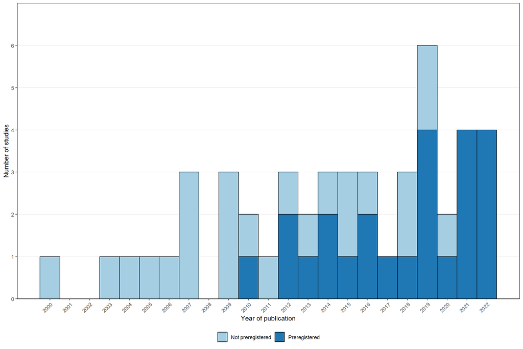

Figure 1: Number of studies included in meta-analysis by year.

````markdown
```{r, time-plot}
#| label: fig-time-plot
#| fig-cap: "Number of studies included in meta-analysis by year."
#| fig-width: 12
#| fig-height: 8
#| message: false

# Figure 1: Number of included studies in the meta-analysis by year
G_timeplot <-
  group_based_dat |>
  mutate(
    prereg = if_else(
      str_detect(protocol, regex("yes", ignore_case = TRUE)),
      "Preregistered", "Not preregistered"
    )
  ) |>
  reframe(year = unique(year), prereg = unique(prereg), .by =  study)

# DONE
timeline_plot <-  ggplot(G_timeplot, aes(x = year, fill = prereg)) +
  geom_bar(col = "black", alpha = 1, width = 1) +
  scale_x_continuous(breaks = seq(2000, 2022, 1)) +
  scale_y_continuous(breaks = seq(0, 6.5, 1), limits = c(0, 7), expand = c(0,0)) +
  theme_bw() +
  scale_fill_brewer(palette="Paired")+
  theme(
    axis.text.x = element_text(angle = 45, vjust = 1, hjust = 1),
    #panel.border = element_blank(),
    legend.position = "bottom",
    legend.title = element_blank(),
    panel.grid.minor = element_blank(),
    panel.grid.major.x = element_blank(),
    axis.line = element_line(colour = "black")
  ) +
  labs(
    x = "Year of publication",
    y = "Number of studies",
  )

timeline_plot
```
````

## Number effects across effect size metrics

````markdown
```{r}
# Number of studies reporting OR
group_based_dat |>
  summarise(
    n = n(),
    .by = c(study, effect_size)
  ) |>
  summarise(
    N_studies = length(effect_size),
    N_es = sum(n),
    .by = effect_size
  )
```
````

```
# A tibble: 2 × 3
  effect_size N_studies  N_es
  <chr>           <int> <int>
1 SMD                48   388
2 OR                  1     2
```

## Number of effect size estimates per study

### Overall per study

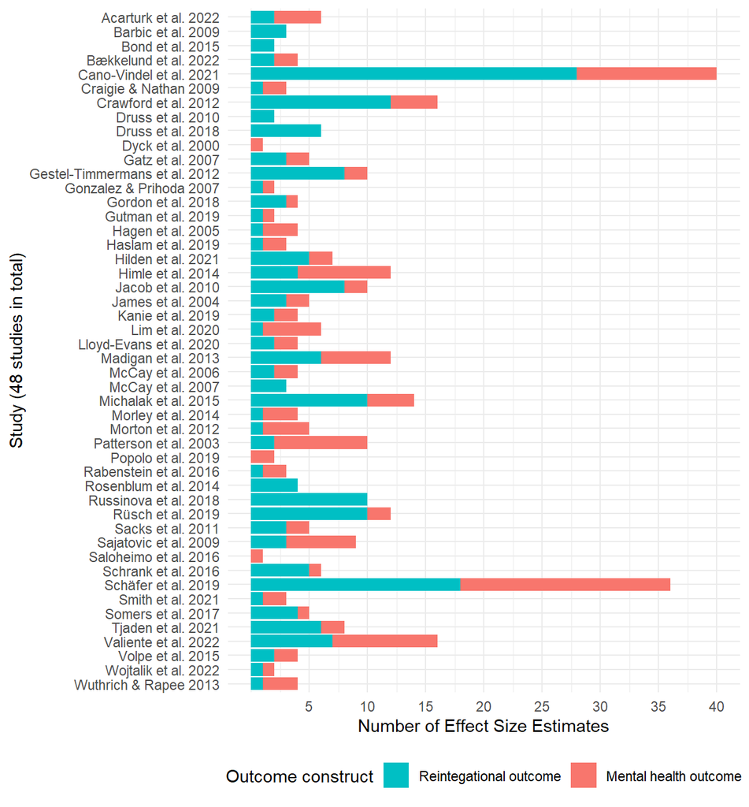

Figure 2: Distribution of number of effect size estimates per study

````markdown
```{r es-plot}
#| label: fig-es-hist-per-stud
#| fig-cap: "Distribution of number of effect size estimates per study"
#| fig.width: 6.5
#| fig.height: 7
#| message: false

es_plot_per_study <-
  gb_dat |>
  arrange(desc(study)) |>
  mutate(study = factor(study, unique(study))) |>
  ggplot(aes(x = study)) +
  geom_bar(aes(fill = outcome_construct)) +
  scale_y_continuous(breaks = seq(5, 40, by = 5)) +
  theme_minimal() +
  theme(
    legend.position = "bottom"
  ) +
  coord_flip() +
  labs(
    x = paste0("Study (", n_distinct(gb_dat$study), " studies in total)"),
    y = "Number of Effect Size Estimates",
    fill = "Outcome construct"
  ) +
  guides(fill = guide_legend(reverse=TRUE))

es_plot_per_study
```
````

### Across outcome subgroups per study

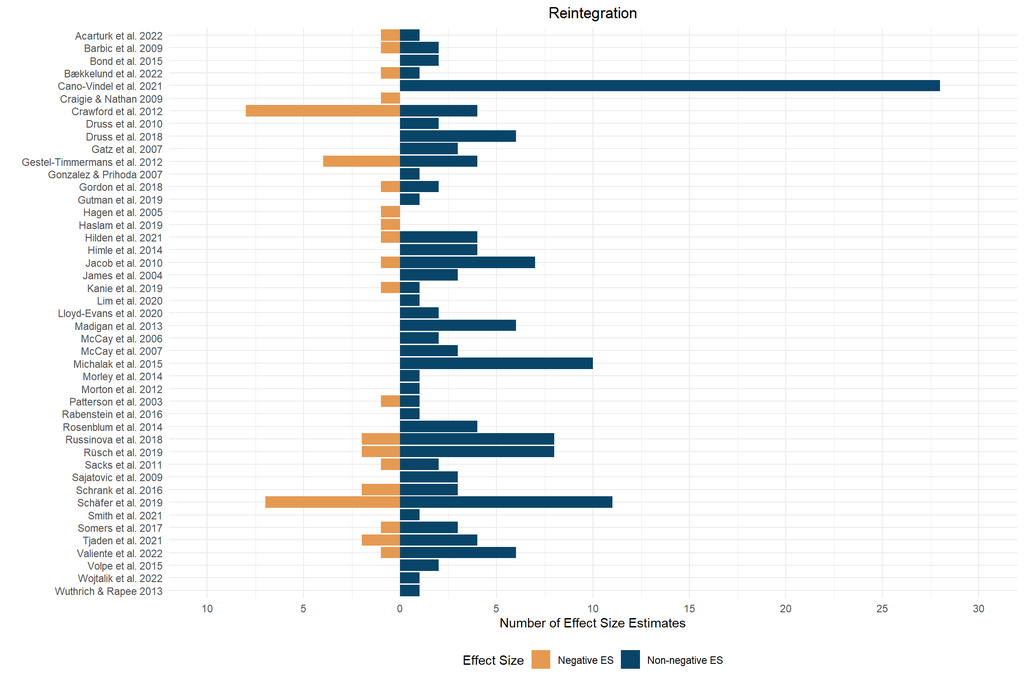

Figure 3: Distribution of number of effects per study, by direction of the effects for reintegrational outcomes.

````markdown
```{r es-plot-reint}
#| label: fig-es-hist-per-stud-reint
#| fig-cap: "Distribution of number of effects per study, by direction of the effects for reintegrational outcomes."
#| fig-width: 12
#| fig-height: 8
#| message: false

reintergation_dat |>
ggplot(aes(y = study, fill = gt_pop >= 0)) +
geom_bar(data = subset(reintergation_dat, gt_pop >= 0), aes(x = after_stat(count)), stat = "count") +
geom_bar(data = subset(reintergation_dat, gt_pop < 0), aes(x = -after_stat(count)), stat = "count") +
theme_minimal() +
scale_x_continuous(labels = abs, breaks = scales::breaks_width(5), limits = c(-10, 30)) +
scale_y_discrete(limits=rev) +
scale_fill_manual(
  values = c(met.brewer("Navajo")[2], met.brewer("Navajo")[4]),
  labels = c("Negative ES", "Non-negative ES"),
  name = "Effect Size"
) +
labs(x = "Number of Effect Size Estimates", y = "", title = "Reintegration") +
theme(
    legend.position = "bottom",
    #legend.position.inside = c(0.95, 0.05),
    #legend.justification = c(1, 0),
    legend.background = element_blank(),
    plot.title = element_text(hjust = 0.5)
  )
```
````

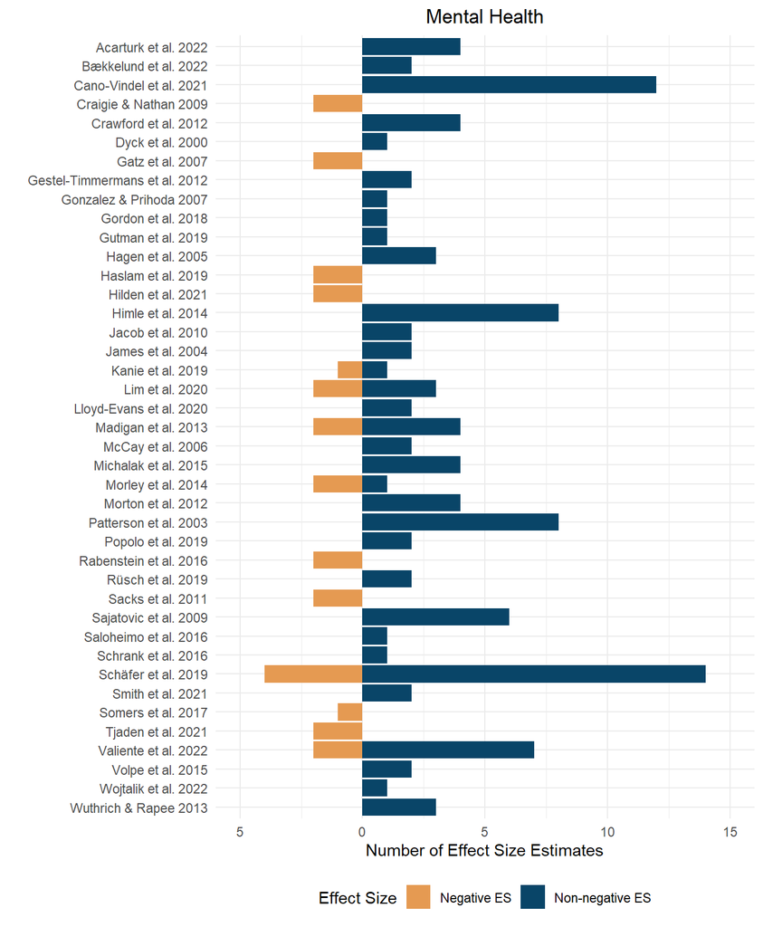

Figure 4: Distribution of number of effects per study, by direction of the effects for mental health outcomes.

````markdown
```{r es-plot-mental}
#| label: fig-es-hist-per-stud-mental
#| fig-cap: "Distribution of number of effects per study, by direction of the effects for mental health outcomes."
#| fig-height: 8.5
#| message: false

mental_health_dat |>
ggplot(aes(y = study, fill = gt_pop >= 0)) +
geom_bar(data = subset(mental_health_dat, gt_pop >= 0), aes(x = after_stat(count)), stat = "count") +
geom_bar(data = subset(mental_health_dat, gt_pop < 0), aes(x = -after_stat(count)), stat = "count") +
theme_minimal() +
scale_x_continuous(labels = abs, breaks = scales::breaks_width(5), limits = c(-5, 15)) +
scale_y_discrete(limits=rev) +
scale_fill_manual(
  values = c(met.brewer("Navajo")[2], met.brewer("Navajo")[4]),
  labels = c("Negative ES", "Non-negative ES"),
  name = "Effect Size"
) +
labs(x = "Number of Effect Size Estimates", y = "", title = "Mental Health") +
theme(
    legend.position = "bottom",
    #legend.position.inside = c(0.95, 0.2),
    #legend.justification = c(1, 0),
    legend.background = element_blank(),
    plot.title = element_text(hjust = 0.5)
  )
```
````

### Overall across all studies and outcomes

````markdown
```{r structure}
# Multi-arms studies
multi_arm_studies <-
  gb_dat |>
  filter(trt_id > 1) |>
  reframe(study = unique(study))


# Multi-time-points studies
follow_up_studies <-
  gb_dat |>
  summarise(
    time_points = length(unique(time_after_end_intervention_weeks)),
    .by = c(study, trt_id, ctr_id)
  ) |>
  filter(time_points > 1)

# Preregistered studies
prereg_studies <-
  gb_dat |>
  summarise(
    prereg_chr = unique(prereg_chr),
    n_es = n(),
    .by = study
  ) |>
  summarise(
    N_studies = n_distinct(study),
    N_es = sum(n_es),
    .by = prereg_chr
  )

study_sample_sizes <-
  gb_dat |>
  group_by(study, trt_id, ctr_id) |>
  summarise(
    effects = n(),
    participants = max(N_total)
  ) |>
  summarise(
    effects = sum(effects),
    participants = mean(participants),
    ctl_comparisons = n(),
    ctl_arms = paste(ctr_id, collapse = "; ")
  ) |>
  group_by(study, ctl_arms) |>
  summarise(
    effects = sum(effects),
    participants = mean(participants * (1 + ctl_comparisons * (n() - 1) / 2)),
    trt_comparisons = n(),
    trt_arms = paste(trt_id, collapse = "; "),
    ctl_comparisons = mean(ctl_comparisons)
  ) |>
  summarise(
    effects = sum(effects),
    participants = sum(participants),
    trt_comparisons = mean(trt_comparisons),
    ctl_comparisons = sum(ctl_comparisons)
  )

sample_size_summary <-
  study_sample_sizes |>
  summarise(
    studies = n(),
    studies_multiple_tx = sum(trt_comparisons > 1),
    studies_multiple_ctl = sum(ctl_comparisons > 1),
    n_effects = sum(effects),
    mean_effects = mean(effects),
    min_effects = min(effects),
    median_effects = median(effects),
    max_effects = max(effects),
    participants = round(sum(participants))
  ) |>
  mutate(prereg = prereg_studies$N_studies[1])

n_studies <- sample_size_summary$studies
```
````

````markdown
```{r structure-table}
#| tbl-cap-location: top
#| label: tab-es-structure

kable(
  sample_size_summary,
  caption = "Data structure for the all data",
  col.names = c(
    studies = "Studies",
    studies_multiple_tx = "Multi-treatment studies",
    studies_multiple_ctl = "Multi-control studies",
    n_effects = "Effects",
    mean_effects = "Mean",
    min_effects = "Minimum",
    median_effects = "Median",
    max_effects = "Maximum",
    participants = "Participants",
    prereg = "Preregistered studies"
  ),
  digits = 1
) |>
  kable_styling(bootstrap_options = c("striped", "condensed"),
                full_width = FALSE)
```
````

Data structure for the all data

| Studies | Multi-treatment studies | Multi-control studies | Effects | Mean | Minimum | Median | Maximum | Participants | Preregistered studies |
| --- | --- | --- | --- | --- | --- | --- | --- | --- | --- |
| 48 | 3 | 0 | 343 | 7.1 | 1 | 4.5 | 40 | 5527 | 24 |

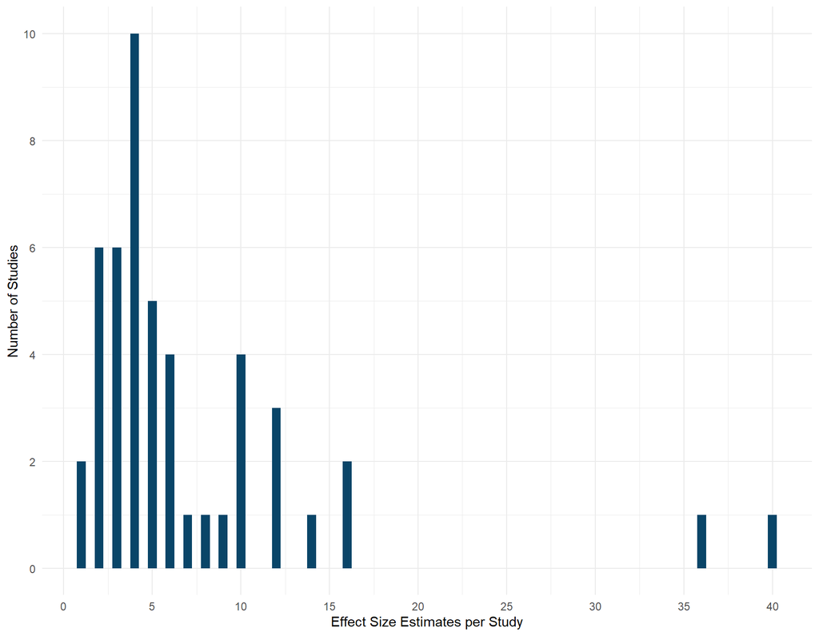

Figure 5: Distribution of number of effect size estimates per study

````markdown
```{r, sum-es-per-study-plot}
#| label: fig-es-hist
#| fig-cap: "Distribution of number of effect size estimates per study"
#| fig.width: 9
#| fig.height: 7
#| message: false

gb_dat |>
  summarise(
    es_count = n(),
    .by = study
  ) |>
  arrange(es_count) |>
  ggplot(aes(x = es_count)) +
  geom_histogram(binwidth = 0.5, fill = met.brewer("Navajo")[4]) +
  scale_x_continuous(breaks = seq(0, 40, by = 5)) +
  scale_y_continuous(breaks = seq(0, 10, 2)) +
  theme_minimal() +
  labs(x = "Effect Size Estimates per Study", y = "Number of Studies")
```
````

### Across outcome subgroups

````markdown
```{r structure-reint}
# Multi-arms studies
multi_arm_studies_reint <-
  reintergation_dat |>
  filter(trt_id > 1) |>
  reframe(study = unique(study))


# Multi-time-points studies
follow_up_studies_reint <-
  reintergation_dat |>
  summarise(
    time_points = length(unique(time_after_end_intervention_weeks)),
    .by = c(study, trt_id, ctr_id)
  ) |>
  filter(time_points > 1)

# Preregistered studies
prereg_studies_reint <-
  reintergation_dat |>
  summarise(
    prereg_chr = unique(prereg_chr),
    n_es = n(),
    .by = study
  ) |>
  summarise(
    N_studies = n_distinct(study),
    N_es = sum(n_es),
    .by = prereg_chr
  )

study_sample_sizes_reint <-
  reintergation_dat |>
  group_by(study, trt_id, ctr_id) |>
  summarise(
    effects = n(),
    participants = max(N_total)
  ) |>
  summarise(
    effects = sum(effects),
    participants = mean(participants),
    ctl_comparisons = n(),
    ctl_arms = paste(ctr_id, collapse = "; ")
  ) |>
  group_by(study, ctl_arms) |>
  summarise(
    effects = sum(effects),
    participants = mean(participants * (1 + ctl_comparisons * (n() - 1) / 2)),
    trt_comparisons = n(),
    trt_arms = paste(trt_id, collapse = "; "),
    ctl_comparisons = mean(ctl_comparisons)
  ) |>
  summarise(
    effects = sum(effects),
    participants = sum(participants),
    trt_comparisons = mean(trt_comparisons),
    ctl_comparisons = sum(ctl_comparisons)
  )

sample_size_summary_reint <-
  study_sample_sizes_reint |>
  summarise(
    studies = n(),
    studies_multiple_tx = sum(trt_comparisons > 1),
    studies_multiple_ctl = sum(ctl_comparisons > 1),
    n_effects = sum(effects),
    mean_effects = mean(effects),
    min_effects = min(effects),
    median_effects = median(effects),
    max_effects = max(effects),
    participants = round(sum(participants))
  ) |>
  mutate(prereg = prereg_studies_reint$N_studies[1])

n_studies_reint <- sample_size_summary_reint$studies
```
````

````markdown
```{r structure-table-reint}
#| tbl-cap-location: top
#| label: tab-es-structure-reint

kable(
  sample_size_summary_reint,
  caption = "Data structure for the reintegrational data",
  col.names = c(
    studies = "Studies",
    studies_multiple_tx = "Multi-treatment studies",
    studies_multiple_ctl = "Multi-control studies",
    n_effects = "Effects",
    mean_effects = "Mean",
    min_effects = "Minimum",
    median_effects = "Median",
    max_effects = "Maximum",
    participants = "Participants",
    prereg = "Preregistered studies"
  ),
  digits = 1
) |>
  kable_styling(bootstrap_options = c("striped", "condensed"),
                full_width = FALSE)
```
````

Data structure for the reintegrational data

| Studies | Multi-treatment studies | Multi-control studies | Effects | Mean | Minimum | Median | Maximum | Participants | Preregistered studies |
| --- | --- | --- | --- | --- | --- | --- | --- | --- | --- |
| 45 | 3 | 0 | 202 | 4.5 | 1 | 3 | 28 | 5390 | 23 |

````markdown
```{r structure-mental}
# Multi-arms studies
multi_arm_studies_mental <-
  mental_health_dat |>
  filter(trt_id > 1) |>
  reframe(study = unique(study))


# Multi-time-points studies
follow_up_studies_mental <-
  mental_health_dat |>
  summarise(
    time_points = length(unique(time_after_end_intervention_weeks)),
    .by = c(study, trt_id, ctr_id)
  ) |>
  filter(time_points > 1)

# Preregistered studies
prereg_studies_mental <-
  mental_health_dat |>
  summarise(
    prereg_chr = unique(prereg_chr),
    n_es = n(),
    .by = study
  ) |>
  summarise(
    N_studies = n_distinct(study),
    N_es = sum(n_es),
    .by = prereg_chr
  )

study_sample_sizes_mental <-
  mental_health_dat |>
  group_by(study, trt_id, ctr_id) |>
  summarise(
    effects = n(),
    participants = max(N_total)
  ) |>
  summarise(
    effects = sum(effects),
    participants = mean(participants),
    ctl_comparisons = n(),
    ctl_arms = paste(ctr_id, collapse = "; ")
  ) |>
  group_by(study, ctl_arms) |>
  summarise(
    effects = sum(effects),
    participants = mean(participants * (1 + ctl_comparisons * (n() - 1) / 2)),
    trt_comparisons = n(),
    trt_arms = paste(trt_id, collapse = "; "),
    ctl_comparisons = mean(ctl_comparisons)
  ) |>
  summarise(
    effects = sum(effects),
    participants = sum(participants),
    trt_comparisons = mean(trt_comparisons),
    ctl_comparisons = sum(ctl_comparisons)
  )

sample_size_summary_mental <-
  study_sample_sizes_mental |>
  summarise(
    studies = n(),
    studies_multiple_tx = sum(trt_comparisons > 1),
    studies_multiple_ctl = sum(ctl_comparisons > 1),
    n_effects = sum(effects),
    mean_effects = mean(effects),
    min_effects = min(effects),
    median_effects = median(effects),
    max_effects = max(effects),
    participants = round(sum(participants))
  ) |>
  mutate(prereg = prereg_studies_mental$N_studies[1])

n_studies_mental <- sample_size_summary_mental$studies
```
````

````markdown
```{r structure-table-mental}
#| tbl-cap-location: top
#| label: tab-es-structure-mental

kable(
  sample_size_summary_mental,
  caption = "Data structure for the mental health data",
  col.names = c(
    studies = "J",
    studies_multiple_tx = "M-t",
    studies_multiple_ctl = "M-c",
    n_effects = "ES",
    mean_effects = "Mean",
    min_effects = "Min",
    median_effects = "Median",
    max_effects = "Max",
    participants = "N",
    prereg = "Prereg"
  ),
  digits = 1
) |>
  kable_styling(bootstrap_options = c("striped", "condensed"),
                full_width = FALSE)
```
````

Data structure for the mental health data

| J | M-t | M-c | ES | Mean | Min | Median | Max | N | Prereg |
| --- | --- | --- | --- | --- | --- | --- | --- | --- | --- |
| 41 | 3 | 0 | 141 | 3.4 | 1 | 2 | 18 | 4663 | 21 |

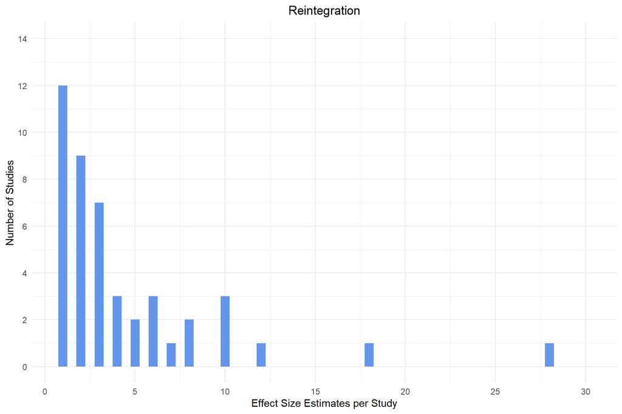

Figure 6: Distribution of number of effects per study for mental for reintegrational outcomes.

````markdown
```{r sum-es-plot-reint}
#| label: fig-es-hist-reint
#| fig-cap: "Distribution of number of effects per study for mental for reintegrational outcomes."
#| fig-width: 9
#| fig-height: 6
#| message: false

reintergation_dat |>
  summarise(
    es_count = n(),
    .by = study
  ) |>
  arrange(es_count) |>
  ggplot(aes(x = es_count)) +
  geom_histogram(binwidth = 0.5, fill = "cornflowerblue") +
  scale_x_continuous(breaks = seq(0, 30, by = 5)) +
  scale_y_continuous(breaks = seq(0, 14, 2), limits = c(0, 14)) +
  theme_minimal() +
  theme(plot.title = element_text(hjust = 0.5)) +
  labs(x = "Effect Size Estimates per Study", y = "Number of Studies", title = "Reintegration") +
  expand_limits(x = 30)
```
````

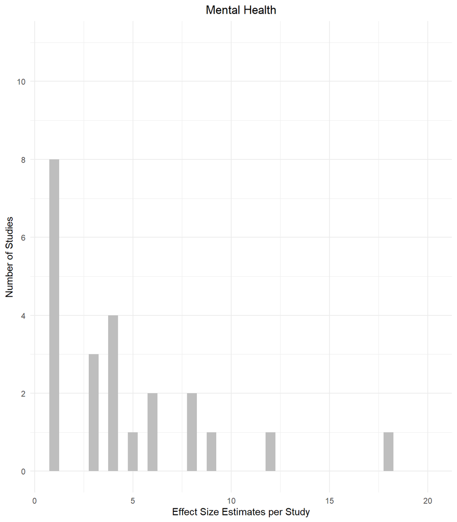

Figure 7: Distribution of number of effects per study for mental health outcomes.

````markdown
```{r es-plot-mental}
#| label: fig-es-hist-mental
#| fig-cap: "Distribution of number of effects per study for mental health outcomes."
#| fig-height: 8
#| message: false

mental_health_dat |>
  summarise(
    es_count = n(),
    .by = study
  ) |>
  arrange(es_count) |>
  ggplot(aes(x = es_count)) +
  geom_histogram(binwidth = 0.5, fill = "gray") +
  scale_x_continuous(breaks = seq(0, 20, by = 5)) +
  scale_y_continuous(breaks = seq(0, 10, 2), limits = c(0, 11)) +
  theme_minimal() +
  theme(plot.title = element_text(hjust = 0.5)) +
  labs(x = "Effect Size Estimates per Study", y = "Number of Studies", title = "Mental Health") +
  expand_limits(x = 20)
```
````

## Data structure by outcome constructs

````markdown
```{r labeled-cat-hist-ridge-function}
label_cat_hist_ridge <- function(data, n_es, variable, label_map, level_order) {
  require(dplyr)
  require(rlang)
  require(tidyr)
  require(ggplot2)
  require(forcats)

  n_es_exp <- enquo(n_es)
  var_exp <- enquo(variable)

  data <- data |>
    mutate(
      !!var_exp := fct_recode(!!var_exp, !!!label_map),
      !!var_exp := fct_relevel(!!var_exp, !!!level_order),
      !!var_exp := fct_rev(!!var_exp)
    )

  ggplot(data, aes(
    x = !!n_es_exp,
    y = !!var_exp,
    fill = !!var_exp
  )) +
    geom_density_ridges(
      alpha = 1,
      stat = "binline",
      bins = 30,
      scale = 0.7,
      linewidth = 0.1,
      draw_baseline = FALSE
    ) +
    theme_minimal() +
    labs(y = "", x = "Effect Size Estimates per Study") +
    theme(legend.position = "none")
}
```
````

The following plot shows the effect size estimates distribution within each outcome construct.

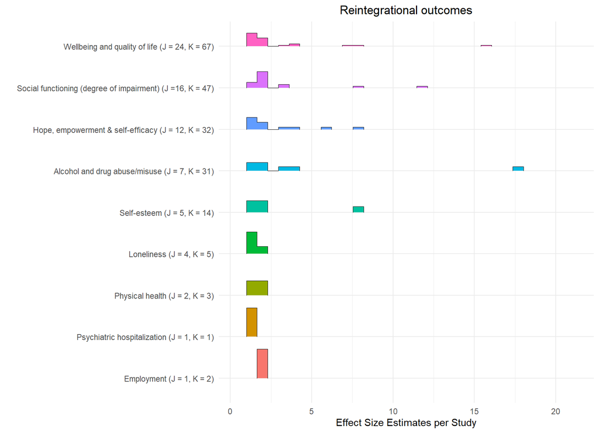

Figure 8: Distribution of effect size estimates, by reintegrational outcome constructs.

````markdown
```{r outcome-construct-ridge-hist}
#| label: fig-outcome-construct-ridge-hist
#| fig-cap: "Distribution of effect size estimates, by reintegrational outcome constructs."
#| fig.width: 9
#| fig.height: 6.5
#| fig.retina: 2
#| message: false

n_es_by_construct <-
  gb_dat |>
  filter(str_detect(outcome_construct, "Re")) |>
  summarise(effects = n(), .by = c(study, analysis_plan)) |>
  mutate(J = n(), .by = c(analysis_plan)) |>
  arrange(desc(J))

# Used to construct out_label
#label_dat <-
#  n_es_by_construct |>
#  summarise(J = n(), N_es = sum(effects), .by = analysis_plan)


out_label <- c(
  "Wellbeing and quality of life (J = 24, K = 67)" = "Wellbeing and quality of life",
  "Social functioning (degree of impairment) (J =16, K = 47)" = "Social functioning (degree of impairment)",
  "Hope, empowerment & self-efficacy (J = 12, K = 32)" = "Hope, empowerment & self-efficacy",
  "Alcohol and drug abuse/misuse (J = 7, K = 31)" = "Alcohol and drug abuse/misuse",
  "Self-esteem (J = 5, K = 14)" = "Self-esteem",
  "Loneliness (J = 4, K = 5)" = "Loneliness",
  "Physical health (J = 2, K = 3)" = "Physical health",
  "Psychiatric hospitalization (J = 1, K = 1)" = "Psychiatric hospitalization",
  "Employment (J = 1, K = 2)" = "Employment"
)

out_level <- c(
 "Wellbeing and quality of life (J = 24, K = 67)",
  "Social functioning (degree of impairment) (J =16, K = 47)",
  "Hope, empowerment & self-efficacy (J = 12, K = 32)",
  "Alcohol and drug abuse/misuse (J = 7, K = 31)",
  "Self-esteem (J = 5, K = 14)",
  "Loneliness (J = 4, K = 5)",
  "Physical health (J = 2, K = 3)",
  "Psychiatric hospitalization (J = 1, K = 1)",
  "Employment (J = 1, K = 2)"
)

label_cat_hist_ridge(
  data = n_es_by_construct,
  n_es = effects,
  variable = analysis_plan,
  label_map = out_label,
  level_order = out_level
) +
  expand_limits(x = 20) +
  labs(title = "Reintegrational outcomes") +
  theme(plot.title = element_text(hjust = 0.5))
```
````

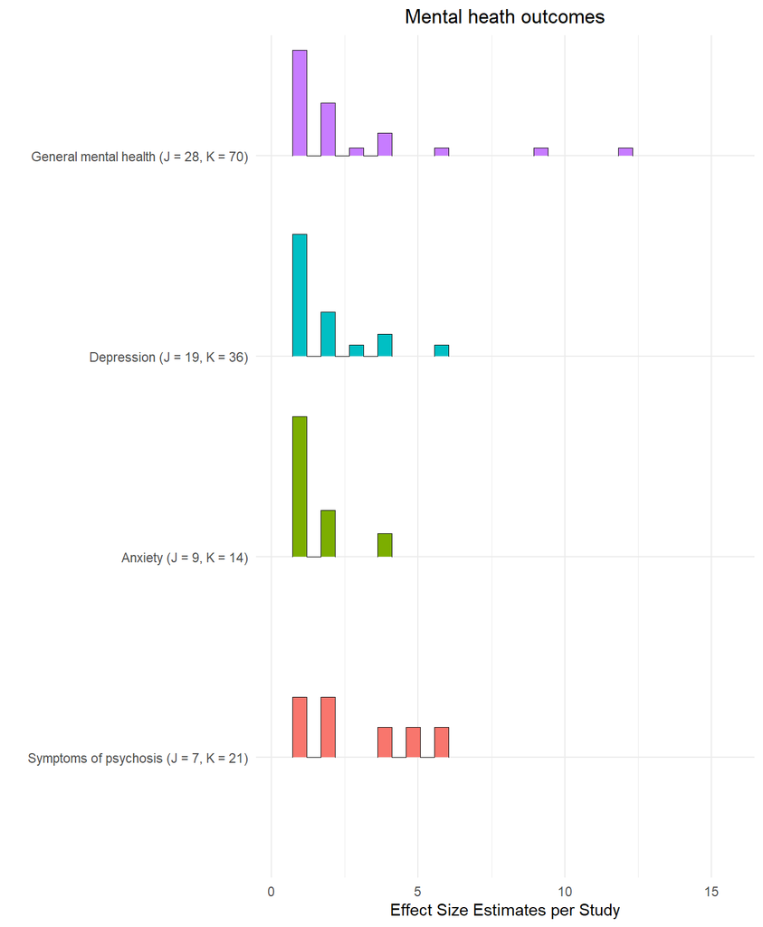

Figure 9: Distribution of effect size estimates, by mental health outcome constructs.

````markdown
```{r outcome-construct-ridge-hist-mental}
#| label: fig-outcome-construct-ridge-hist-mental
#| fig-cap: "Distribution of effect size estimates, by mental health outcome constructs."
#| fig.height: 8.5
#| fig.retina: 2
#| message: false

n_es_by_construct_mental <-
  gb_dat |>
  filter(str_detect(outcome_construct, "Men")) |>
  summarise(effects = n(), .by = c(study, analysis_plan)) |>
  mutate(J = n(), .by = c(analysis_plan)) |>
  arrange(desc(J))

# Used to construct out_label_mental
#label_dat_mental <-
#  n_es_by_construct_mental |>
#  summarise(J = n(), N_es = sum(effects), .by = analysis_plan)

out_label_mental <- c(
  "General mental health (J = 28, K = 70)" = "General mental health",
  "Depression (J = 19, K = 36)" = "Depression",
  "Anxiety (J = 9, K = 14)" = "Anxiety",
  "Symptoms of psychosis (J = 7, K = 21)" = "Symptoms of psychosis"
)

out_level_mental <- c(
  "General mental health (J = 28, K = 70)",
  "Depression (J = 19, K = 36)",
  "Anxiety (J = 9, K = 14)",
  "Symptoms of psychosis (J = 7, K = 21)"
)

label_cat_hist_ridge(
  data = n_es_by_construct_mental,
  n_es = effects,
  variable = analysis_plan,
  label_map = out_label_mental,
  level_order = out_level_mental
) +
  expand_limits(x = 15) +
  labs(title = "Mental heath outcomes") +
  theme(plot.title = element_text(hjust = 0.5))
```
````

## Primary study sample size

### Total sample sizes

````markdown
```{r sample-size-overall-reint}
#| tbl-cap-location: top
#| label: tab-sample-size

# Used when describing the treatment group sample sizes
N_t_stud_trtid <-
  reintergation_dat |>
  reframe(N_treat = max(N_t), .by = c(study, trt_id))

N_t_total <-
  N_t_stud_trtid |>
  summarise(N_t_total = sum(N_treat), .by = study)

N_c_total <-
  reintergation_dat |>
  summarise(N_c_total = max(N_c), .by = study)

N_total_dat <-
  left_join(N_t_total, N_c_total, by = join_by(study)) |>
  mutate(N_total = N_t_total + N_c_total)


primary_sample_size_descriptive <-
  N_total_dat$N_total |>
  skim() |>
  select(-skim_type, -skim_variable, -n_missing, -complete_rate, -numeric.hist) |>
  rename_at(vars(starts_with("numeric.")), ~ str_remove(., "numeric\\."))

primary_sample_size_descriptive |>
  knitr::kable(
    digits = 2,
    caption = "Distribution of primary study sample sizes at post test for reintegrational outcomes",
    booktabs = TRUE
  ) |>
  kable_styling(bootstrap_options = c("striped","condensed"), full_width = FALSE)
```
````

Distribution of primary study sample sizes at post test for reintegrational outcomes

| mean | sd | p0 | p25 | p50 | p75 | p100 |
| --- | --- | --- | --- | --- | --- | --- |
| 119.78 | 127.69 | 17 | 41 | 61 | 137 | 631 |

````markdown
```{r sample-size-overall-mental}
#| tbl-cap-location: top
#| label: tab-sample-size-mental

# Used when describing the treatment group sample sizes
N_t_stud_trtid_mental <-
  mental_health_dat |>
  reframe(N_treat = max(N_t), .by = c(study, trt_id))

N_t_total_mental <-
  N_t_stud_trtid_mental |>
  summarise(N_t_total = sum(N_treat), .by = study)

N_c_total_mental <-
  mental_health_dat |>
  summarise(N_c_total = max(N_c), .by = study)

N_total_dat_mental <-
  left_join(N_t_total_mental, N_c_total_mental, by = join_by(study)) |>
  mutate(N_total = N_t_total + N_c_total)


primary_sample_size_descriptive_mental <-
  N_total_dat_mental$N_total |>
  skim() |>
  select(-skim_type, -skim_variable, -n_missing, -complete_rate, -numeric.hist) |>
  rename_at(vars(starts_with("numeric.")), ~ str_remove(., "numeric\\."))

primary_sample_size_descriptive_mental |>
  knitr::kable(
    digits = 2,
    caption = "Distribution of primary study sample sizes at post test for mental health outcomes",
    booktabs = TRUE
  ) |>
  kable_styling(bootstrap_options = c("striped","condensed"), full_width = FALSE)
```
````

Distribution of primary study sample sizes at post test for mental health outcomes

| mean | sd | p0 | p25 | p50 | p75 | p100 |
| --- | --- | --- | --- | --- | --- | --- |
| 113.73 | 125.6 | 17 | 40 | 61 | 128 | 631 |

The following plot displays the distribution of study sample sizes at post-test.

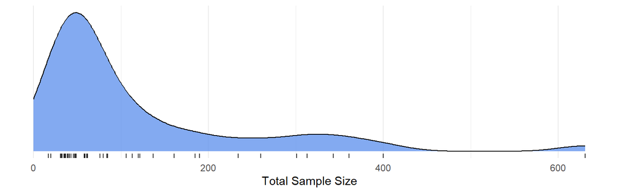

Figure 10: Distribution of primary study sample sizes at post test for reintegrational outcomes.

````markdown
```{r sample-size-plot-reint}
#| label: fig-sample-size-reint
#| fig-cap: "Distribution of primary study sample sizes at post test for reintegrational outcomes."
#| fig.height: 2.5
#| fig.width: 8
#| fig.retina: 2
#| message: false
study_sizes_plot_reint <-
  ggplot(N_total_dat, aes(N_total)) +
  geom_density(fill = "cornflowerblue", alpha = 0.8) +
  geom_blank(aes(x = 0, y = 0)) +
  geom_rug(alpha = 0.8) +
  scale_y_continuous(NULL, breaks = NULL) +
  theme_minimal() +
  labs(x = "Total Sample Size", y = "")
study_sizes_plot_reint
```
````

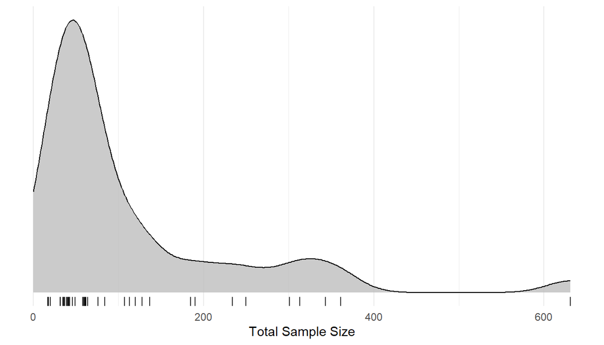

Figure 11: Distribution of primary study sample sizes at post test for mental health outcomes.

````markdown
```{r sample-size-plot-mental}
#| label: fig-sample-size-mental
#| fig-cap: "Distribution of primary study sample sizes at post test for mental health outcomes."
#| fig.height: 4
#| fig.retina: 2
#| message: false
study_sizes_plot_mental <-
  ggplot(N_total_dat_mental, aes(N_total)) +
  geom_density(fill = "gray", alpha = 0.8) +
  geom_blank(aes(x = 0, y = 0)) +
  geom_rug(alpha = 0.8) +
  scale_y_continuous(NULL, breaks = NULL) +
  theme_minimal() +
  labs(x = "Total Sample Size", y = "")
study_sizes_plot_mental
```
````

### Treatment group

````markdown
```{r sample-size-treatment-reint}
#| tbl-cap-location: top
#| label: tab-sample-size-treatment

treatment_sample_size_descriptive <-
  N_t_stud_trtid$N_treat |>
  skim() |>
  select(-skim_type, -skim_variable, -n_missing, -complete_rate, -numeric.hist) |>
  rename_at(vars(starts_with("numeric.")), ~ str_remove(., "numeric\\."))

treatment_sample_size_descriptive |>
  knitr::kable(
    digits = 2,
    caption = "Distribution of treatment sample sizes at post test for reintegrational outcomes",
    booktabs = TRUE
  ) |>
  kable_styling(bootstrap_options = c("striped","condensed"), full_width = FALSE)
```
````

Distribution of treatment sample sizes at post test for reintegrational outcomes

| mean | sd | p0 | p25 | p50 | p75 | p100 |
| --- | --- | --- | --- | --- | --- | --- |
| 60.88 | 60.32 | 8 | 22.75 | 33.5 | 90.25 | 315 |

````markdown
```{r sample-size-treatment-mental}
#| tbl-cap-location: top
#| label: tab-sample-size-treatment-mental

treatment_sample_size_descriptive_mental <-
  N_t_stud_trtid_mental$N_treat |>
  skim() |>
  select(-skim_type, -skim_variable, -n_missing, -complete_rate, -numeric.hist) |>
  rename_at(vars(starts_with("numeric.")), ~ str_remove(., "numeric\\."))

treatment_sample_size_descriptive_mental |>
  knitr::kable(
    digits = 2,
    caption = "Distribution of treatment sample sizes at post test for mental health outcomes",
    booktabs = TRUE
  ) |>
  kable_styling(bootstrap_options = c("striped","condensed"), full_width = FALSE)
```
````

Distribution of treatment sample sizes at post test for mental health outcomes

| mean | sd | p0 | p25 | p50 | p75 | p100 |
| --- | --- | --- | --- | --- | --- | --- |
| 57.8 | 59.09 | 8 | 21 | 30 | 75 | 315 |

The following plot displays the distribution of treatment sample sizes at post-test.

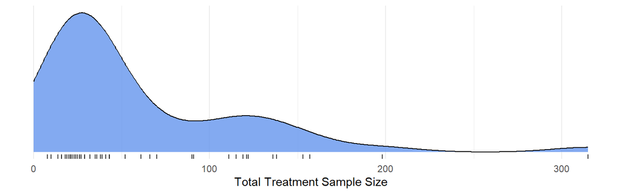

Figure 12: Distribution of treatment sample sizes at post test for reintegrational outcomes.

````markdown
```{r sample-size-treatment-plot-reint}
#| label: fig-sample-size-treatment-reint
#| fig-cap: "Distribution of treatment sample sizes at post test for reintegrational outcomes."
#| fig.height: 2.5
#| fig.width: 8
#| fig.retina: 2
#| message: false
treatment_sizes_plot_reint <-
  ggplot(N_t_stud_trtid, aes(N_treat)) +
  geom_density(fill = "cornflowerblue", alpha = 0.8) +
  geom_blank(aes(x = 0, y = 0)) +
  geom_rug(alpha = 0.8) +
  scale_y_continuous(NULL, breaks = NULL) +
  theme_minimal() +
  labs(x = "Total Treatment Sample Size", y = "")
treatment_sizes_plot_reint
```
````

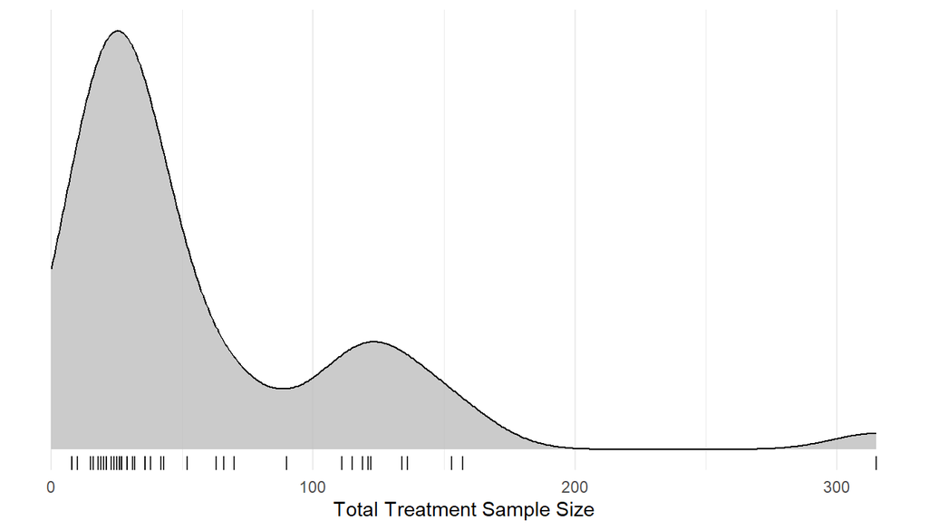

Figure 13: Distribution of treatment sample sizes at post test for mental health outcomes.

````markdown
```{r sample-size-treatment-plot-mental}
#| label: fig-sample-size-treatment-mental
#| fig-cap: "Distribution of treatment sample sizes at post test for mental health outcomes."
#| fig.height: 4
#| fig.retina: 2
#| message: false
treatment_sizes_plot_mental <-
  ggplot(N_t_stud_trtid_mental, aes(N_treat)) +
  geom_density(fill = "gray", alpha = 0.8) +
  geom_blank(aes(x = 0, y = 0)) +
  geom_rug(alpha = 0.8) +
  scale_y_continuous(NULL, breaks = NULL) +
  theme_minimal() +
  labs(x = "Total Treatment Sample Size", y = "")
treatment_sizes_plot_mental
```
````

### Control group

````markdown
```{r sample-size-control-reint}
#| tbl-cap-location: top
#| label: tab-sample-size-control

control_sample_size_descriptive <-
  N_total_dat$N_c_total |>
  skim() |>
  select(-skim_type, -skim_variable, -n_missing, -complete_rate, -numeric.hist) |>
  rename_at(vars(starts_with("numeric.")), ~ str_remove(., "numeric\\."))

control_sample_size_descriptive |>
  knitr::kable(
    digits = 2,
    caption = "Distribution of control group sample sizes at post test for reintegrational outcomes",
    booktabs = TRUE
  ) |>
  kable_styling(bootstrap_options = c("striped","condensed"), full_width = FALSE)
```
````

Distribution of control group sample sizes at post test for reintegrational outcomes

| mean | sd | p0 | p25 | p50 | p75 | p100 |
| --- | --- | --- | --- | --- | --- | --- |
| 54.84 | 60.5 | 9 | 19 | 30 | 63 | 316 |

````markdown
```{r sample-size-control-mental}
#| tbl-cap-location: top
#| label: tab-sample-size-control-mental

control_sample_size_descriptive_mental <-
  N_total_dat_mental$N_c_total |>
  skim() |>
  select(-skim_type, -skim_variable, -n_missing, -complete_rate, -numeric.hist) |>
  rename_at(vars(starts_with("numeric.")), ~ str_remove(., "numeric\\."))

control_sample_size_descriptive_mental |>
  knitr::kable(
    digits = 2,
    caption = "Distribution of control group sample sizes at post test for mental health outcomes",
    booktabs = TRUE
  ) |>
  kable_styling(bootstrap_options = c("striped","condensed"), full_width = FALSE)
```
````

Distribution of control group sample sizes at post test for mental health outcomes

| mean | sd | p0 | p25 | p50 | p75 | p100 |
| --- | --- | --- | --- | --- | --- | --- |
| 51.71 | 58.61 | 9 | 20 | 29 | 63 | 316 |

The following plot displays the distribution of control sample sizes at post-test.

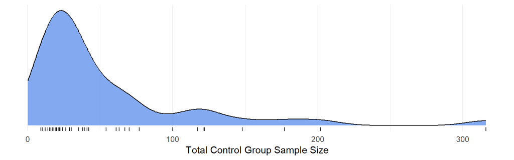

Figure 14: Distribution of control group sample sizes at post test for reintegrational outcomes.

````markdown
```{r sample-size-control-plot-reint}
#| label: fig-sample-size-control-reint
#| fig-cap: "Distribution of control group sample sizes at post test for reintegrational outcomes."
#| fig.height: 2.5
#| fig.width: 8
#| fig.retina: 2
#| message: false
control_sizes_plot_reint <-
  ggplot(N_total_dat, aes(N_c_total)) +
  geom_density(fill = "cornflowerblue", alpha = 0.8) +
  geom_blank(aes(x = 0, y = 0)) +
  geom_rug(alpha = 0.8) +
  scale_y_continuous(NULL, breaks = NULL) +
  theme_minimal() +
  labs(x = "Total Control Group Sample Size", y = "")
control_sizes_plot_reint
```
````

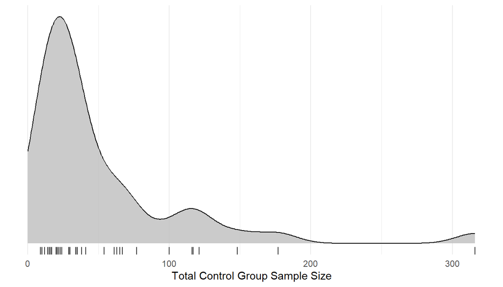

Figure 15: Distribution of control group sample sizes at post test for mental health outcomes.

````markdown
```{r sample-size-control-plot-mental}
#| label: fig-sample-size-control-mental
#| fig-cap: "Distribution of control group sample sizes at post test for mental health outcomes."
#| fig.height: 4
#| fig.retina: 2
#| message: false
control_sizes_plot_mental <-
  ggplot(N_total_dat_mental, aes(N_c_total)) +
  geom_density(fill = "gray", alpha = 0.8) +
  geom_blank(aes(x = 0, y = 0)) +
  geom_rug(alpha = 0.8) +
  scale_y_continuous(NULL, breaks = NULL) +
  theme_minimal() +
  labs(x = "Total Control Group Sample Size", y = "")
control_sizes_plot_mental
```
````

## Study sample sizes versus number of effect size estimates per study

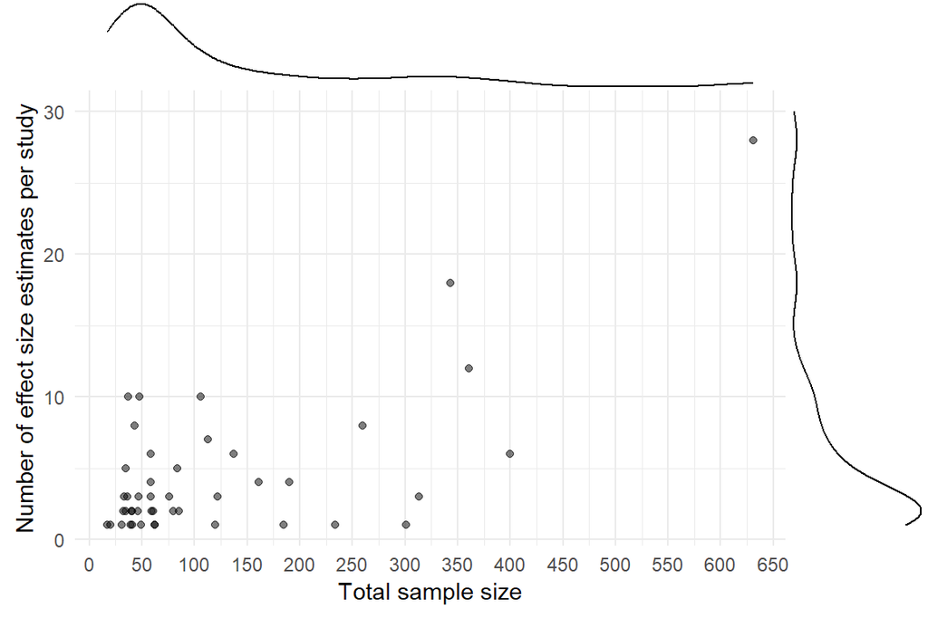

Figure 16: Study sample sizes versus number of effect size estimates for reintegrational outcomes

````markdown
```{r bivariate-es-plot}
#| label: fig-es-distribution-bivariate
#| fig-cap: "Study sample sizes versus number of effect size estimates for reintegrational outcomes"
#| fig.width: 6
#| fig.height: 4
#| fig.retina: 2
#| message: false

plot <-
  reintergation_dat |>
  summarise(effects = n(), .by = study) |>
  left_join(N_total_dat, by = join_by(study)) |>
  relocate(effects, .after = N_total) |>
  ggplot(aes(x = N_total, y = effects)) +
  geom_point(alpha = 0.5) +
  scale_x_continuous(breaks = seq(0, 650, by = 50)) +
  guides(size = "none") +
  theme_minimal() +
  theme(
    legend.position = "inside",
    legend.position.inside = c(0.9, 0.05),
    legend.justification = c(1, 0),
    legend.background = element_blank()
  ) +
  labs(x = "Total sample size", y = "Number of effect size estimates per study", color = "") +
  expand_limits(y = 30)

ggMarginal(plot, type = "density")
```
````

# Moderators

````markdown
```{r cross-tab-function}
cat_dat_cross <- function(variable, study_id, data) {

  require(dplyr)
  require(rlang)
  require(tidyr)

  var_exp <- enquo(variable)
  study_id_exp <- enquo(study_id)
  study_id_name <- as_name(study_id_exp)


    res_dat <- data %>%
      group_by(!!study_id_exp) %>%
      reframe(var_exp_mirror = unique(!!var_exp))  %>%
      full_join(data,
                by = c(study_id_name),
                relationship = "many-to-many") %>%
      group_by(!!var_exp, var_exp_mirror) %>%
      reframe(
        m = n_distinct(!!study_id_exp),
        k = n()
      ) %>%
      mutate(size = paste0(m, " (", k, ")")) %>%
      select(-m, -k) |>
      pivot_wider(names_from = var_exp_mirror, values_from = "size")

  names(res_dat)[1] <- "level"

  res_dat <-
    res_dat |>
    mutate(
      level = factor(level, levels = unique(names(res_dat[-1])))
    ) |>
    arrange(level)

  return(res_dat)
}
```
````

## Categorical moderators

### Outcome measure

````markdown
```{r outcome-dependency-table-reint}
outcome_dat_cross <- cat_dat_cross(
  data = reintergation_dat,
  variable = analysis_plan,
  study_id = study
)

#| tbl-cap-location: top
#| label: tab-outcome

outcome_dat_cross |>
  knitr::kable(
    "html",
    col.names = c(
      "Outcome",
      colnames(outcome_dat_cross)[-1]
    ),
    caption = "Dependency table for preregistration status (reintegration)"
  ) |>
  kableExtra::column_spec(1, bold = TRUE) |>
  kableExtra::footnote(
    general = "Values outside the parentheses are number of studies, with the number of samples and effect size estimates shown in the parentheses.",
    general_title = "Note: ",
    footnote_as_chunk = T
  ) |>
  kableExtra::kable_styling(bootstrap_options = c("striped", "condensed"), full_width = T)
```
````

| Outcome | Alcohol and drug abuse/misuse | Hope, empowerment & self-efficacy | Physical health | Social functioning (degree of impairment) | Wellbeing and quality of life | Employment | Self-esteem | Loneliness | Psychiatric hospitalization |
| --- | --- | --- | --- | --- | --- | --- | --- | --- | --- |
| Alcohol and drug abuse/misuse | 7 (31) | 1 (2) | 1 (1) | 3 (4) | 2 (3) | - | - | - | - |
| Hope, empowerment & self-efficacy | 1 (1) | 12 (32) | - | 1 (2) | 6 (14) | 1 (6) | 3 (15) | 1 (4) | 1 (1) |
| Physical health | 1 (1) | - | 2 (3) | 2 (3) | - | - | - | - | - |
| Social functioning (degree of impairment) | 3 (7) | 1 (2) | 2 (5) | 16 (47) | 7 (30) | - | - | - | - |
| Wellbeing and quality of life | 2 (3) | 6 (12) | - | 7 (34) | 24 (67) | - | 2 (2) | 2 (3) | - |
| Employment | - | 1 (2) | - | - | - | 1 (2) | 1 (2) | - | - |
| Self-esteem | - | 3 (5) | - | - | 2 (2) | 1 (2) | 5 (14) | - | - |
| Loneliness | - | 1 (2) | - | - | 2 (3) | - | - | 4 (5) | - |
| Psychiatric hospitalization | - | 1 (1) | - | - | - | - | - | - | 1 (1) |

Note: Values outside the parentheses are number of studies, with the number of samples and effect size estimates shown in the parentheses.

````markdown
```{r outcome-subgroup-dependency-table-reint}
outcome_subgroup_dat_cross <- cat_dat_cross(
  data = filter(reintergation_dat, str_detect(analysis_plan, "Alco|Hope|Social|Well")),
  variable = analysis_plan,
  study_id = study
)

#| tbl-cap-location: top
#| label: tab-outcome-subgroup

outcome_subgroup_dat_cross |>
  knitr::kable(
    "html",
    col.names = c(
      "Outcome",
      colnames(outcome_subgroup_dat_cross)[-1]
    ),
    caption = "Dependency table for outcome used for subgroup analysis (reintegration)"
  ) |>
  kableExtra::column_spec(1, bold = TRUE) |>
  kableExtra::footnote(
    general = "Values outside the parentheses are number of studies, with the number of samples and effect size estimates shown in the parentheses.",
    general_title = "Note: ",
    footnote_as_chunk = T
  ) |>
  kableExtra::kable_styling(bootstrap_options = c("striped", "condensed"), full_width = T)
```
````

Dependency table for outcome used for subgroup analysis (reintegration)

| Outcome | Alcohol and drug abuse/misuse | Hope, empowerment & self-efficacy | Social functioning (degree of impairment) | Wellbeing and quality of life |
| --- | --- | --- | --- | --- |
| Alcohol and drug abuse/misuse | 7 (31) | 1 (2) | 3 (4) | 2 (3) |
| Hope, empowerment & self-efficacy | 1 (1) | 12 (32) | 1 (2) | 6 (14) |
| Social functioning (degree of impairment) | 3 (7) | 1 (2) | 16 (47) | 7 (30) |
| Wellbeing and quality of life | 2 (3) | 6 (12) | 7 (34) | 24 (67) |

Note: Values outside the parentheses are number of studies, with the number of samples and effect size estimates shown in the parentheses.

````markdown
```{r outcome-subgroup-dependency-table-mental}
outcome_subgroup_dat_cross_mental <- cat_dat_cross(
  data = mental_health_dat,
  variable = analysis_plan,
  study_id = study
)

#| tbl-cap-location: top
#| label: tab-outcome-subgroup-mental

outcome_subgroup_dat_cross_mental |>
  knitr::kable(
    "html",
    col.names = c(
      "Outcome",
      colnames(outcome_subgroup_dat_cross_mental)[-1]
    ),
    caption = "Dependency table for outcome used for subgroup analysis (mental health)"
  ) |>
  kableExtra::column_spec(1, bold = TRUE) |>
  kableExtra::footnote(
    general = "Values outside the parentheses are number of studies, with the number of samples and effect size estimates shown in the parentheses.",
    general_title = "Note: ",
    footnote_as_chunk = T
  ) |>
  kableExtra::kable_styling(bootstrap_options = c("striped", "condensed"), full_width = T)
```
````

Dependency table for outcome used for subgroup analysis (mental health)

| Outcome | Anxiety | Depression | General mental health | Symptoms of psychosis |
| --- | --- | --- | --- | --- |
| Anxiety | 9 (14) | 7 (11) | 5 (9) | - |
| Depression | 7 (10) | 19 (36) | 10 (21) | 2 (4) |
| General mental health | 5 (13) | 10 (27) | 28 (70) | 2 (3) |
| Symptoms of psychosis | - | 2 (8) | 2 (3) | 7 (21) |

Note: Values outside the parentheses are number of studies, with the number of samples and effect size estimates shown in the parentheses.

##### Ridge plot of effect size estimates

````markdown
```{r cat-ridge-function}
cat_ridge <- function(data, es, v, variable) {
  require(dplyr)
  require(rlang)
  require(tidyr)
  require(ggplot2)

  es_exp <- enquo(es)
  var_exp <- enquo(variable)
  v_exp <- enquo(v)

  data |>
    mutate(!!var_exp := fct_rev(!!var_exp)) |>
  ggplot(aes(
    x = !!es_exp,
    y = !!var_exp,
    fill = !!var_exp
  )) +
    geom_density_ridges(
      aes(
        point_colour = !!var_exp,
        point_size = 1 / !!v_exp
      ),
      alpha = .2,
      point_alpha = 0.5,
      jittered_points = TRUE
    ) +
    theme_minimal() +
    labs(y = "", x = "Standardized Mean Difference (Hedges' g)") +
    theme(legend.position = "none")
}
```
````

**Subgroup analyzed**

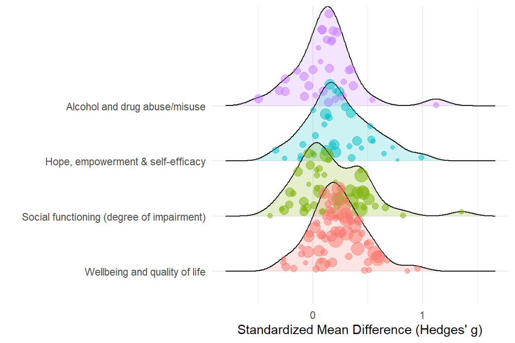

Figure 17: Distribution of effect size estimates, by reintegrational outcomes

````markdown
```{r type-ridge-reint-analyzed}
#| label: fig-type-ridge-reint-analyzed
#| fig-cap: "Distribution of effect size estimates, by reintegrational outcomes"
#| fig.width: 6
#| fig.height: 4
#| fig.retina: 2
#| message: false

analyzed_outcomes <-
  reintergation_dat |>
  filter(str_detect(analysis_plan, "Alco|Hope|Social|Well"))

cat_ridge(data = analyzed_outcomes, es = gt_pop, variable = analysis_plan, v = vgt_pop)
```
````

**Not subgroup analyzed**

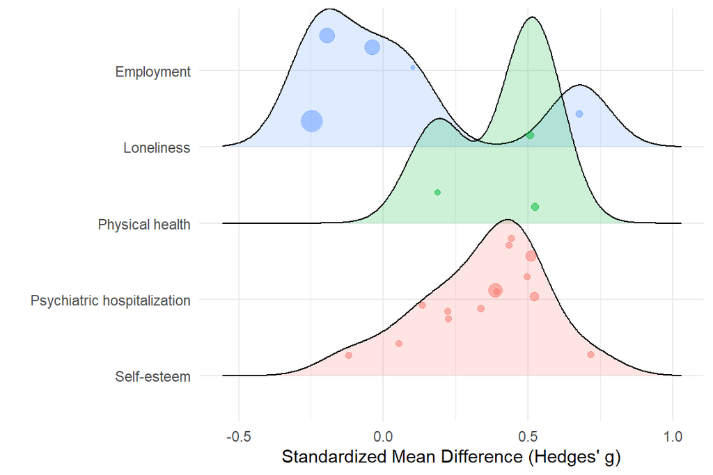

Figure 18: Distribution of effect size estimates, by reintegrational outcomes.

````markdown
```{r type-ridge-reint-not-analyzed}
#| label: fig-type-ridge-reint-not-analyzed
#| fig-cap: "Distribution of effect size estimates, by reintegrational outcomes."
#| fig.width: 6
#| fig.height: 4
#| fig.retina: 2
#| message: false

not_analyzed_outcomes <-
  reintergation_dat |>
  filter(!str_detect(analysis_plan, "Alco|Hope|Social|Well"))

cat_ridge(data = not_analyzed_outcomes, es = gt_pop, variable = analysis_plan, v = vgt_pop)
```
````

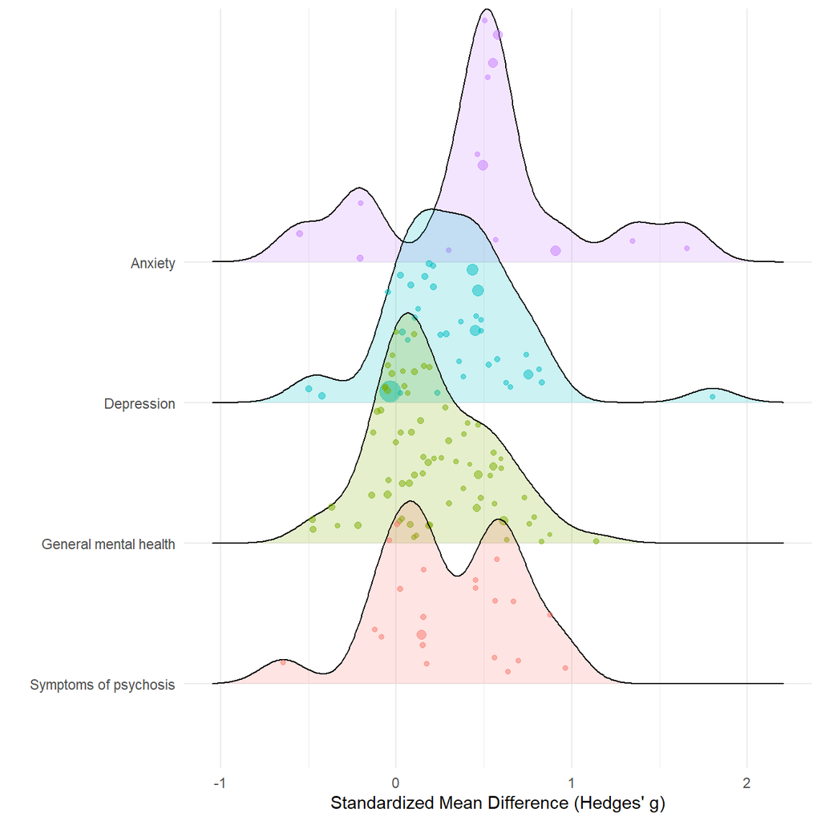

Figure 19: Distribution of effect size estimates, by mental health outcomes.

````markdown
```{r type-ridge-mental-analyzed}
#| label: fig-type-ridge-mental-analyzed
#| fig-cap: "Distribution of effect size estimates, by mental health outcomes."
#| fig.height: 7
#| fig.retina: 2
#| message: false

cat_ridge(data = mental_health_dat, es = gt_pop, variable = analysis_plan, v = vgt_pop)
```
````

##### Network plot for outcome construct

The following plot shows the network structure of outcomes constructs. Each node represent an outcome construct, the edge between a pair of nodes indicates that there is at least one study that examined the contracts between that pair of constructs The width of the edges indicates the number of studies that compare that pair of constructs. The size of the node corresponds to the number of studies measure that construct.

````markdown
```{r incidents}
incidents_matrix <- function(variable, study_id, data) {

  require(dplyr)
  require(rlang)
  require(tidyr)

  var_exp <- enquo(variable)
  study_id_exp <- enquo(study_id)
  study_id_name <- as_name(study_id_exp)


  res_dat <- data %>%
    group_by(!!study_id_exp) %>%
    reframe(var_exp_mirror = unique(!!var_exp))  %>%
    full_join(data,
              by = c(study_id_name),
              relationship = "many-to-many") %>%
    group_by(!!var_exp, var_exp_mirror) %>%
    reframe(
      m = n_distinct(!!study_id_exp),
      k = n()
    ) %>%
    mutate(size = m) %>%
    select(-m, -k) |>
    pivot_wider(names_from = var_exp_mirror, values_from = "size")


  names(res_dat)[1] <- "level"

  return(res_dat)
}
```
````

````markdown
```{r}
gb_dat_reduced <- gb_dat |> select(study, analysis_plan)

res_dat <- gb_dat_reduced %>%
    group_by(study) %>%
    reframe(var_exp_mirror = unique(analysis_plan))  %>%
    full_join(gb_dat_reduced ,
              by = join_by(study),
              relationship = "many-to-many") %>%
    group_by(analysis_plan, var_exp_mirror) %>%
    reframe(
      m = n_distinct(study),
      k = n()
    ) %>%
    mutate(size = m) %>%
    select(-m, -k) |>
    pivot_wider(names_from = var_exp_mirror, values_from = "size")


  names(res_dat)[1] <- "level"


outcome_construct_incidents_matrix <- incidents_matrix(
  variable = analysis_plan,
  study_id = study,
  data = gb_dat
)  |>
  as.data.frame() |>
  relocate(Employment, .after = Depression) |>
  relocate(Loneliness, .before = `Physical health`) |>
  relocate(`Psychiatric hospitalization`, .after = `Physical health`) |>
  relocate(`Self-esteem`, .after = `Psychiatric hospitalization`)

edges <- outcome_construct_incidents_matrix %>%
  rename(from = "level") |>
  pivot_longer(-from, names_to = "to", values_to = "weight") %>%
  filter(from != to, !is.na(weight)) |>
  mutate(
    from_chr = as.character(from),
    to_chr = as.character(to),
    tmp = paste0(pmin(from_chr, to_chr), "_", pmax(from_chr, to_chr))
  ) %>%
  distinct(tmp, .keep_all = TRUE) %>%
  select(from, to, weight)

g <- graph_from_data_frame(edges, directed = FALSE)
```
````

[figure not shown]

Figure 20: Network structure of contrasts between primary and secondary outcome constructs

````markdown
```{r network-plot}
#| label: fig-network
#| fig-cap: "Network structure of contrasts between primary and secondary outcome constructs"
#| fig.width: 7
#| fig.height: 6
#| fig.retina: 2
#| message: false

network_plot <-
  function(
    layout_g, incidents_matrix
    ) {

  layout <- layout_in_circle(layout_g)

  # Adjust label position outward
  label_coords <- layout
  label_coords[, 1] <- c(
    label_coords[1, 1] * 1.35, #1.5,
    label_coords[2:6, 1] * 1.4, #1.63,
    label_coords[7, 1] * 1.35, #1.68,
    label_coords[8:13, 1] * 1.4 #1.63
  )

  label_coords[, 2] <- c(
    label_coords[c(1:3), 2],
    label_coords[4, 2] * 1.13,
    label_coords[5, 2] * 1.27,
    label_coords[6, 2] * 1.13,
    label_coords[c(7:10), 2] * 1.13,
    label_coords[11, 2] * 1.2,
    label_coords[12:13, 2] * 1.13
  )

  node_sizes <- diag(as.matrix(incidents_matrix[, -1]))

  plot(
    g,
    layout = layout,
    edge.width = E(layout_g)$weight,
    edge.color = met.brewer("Navajo")[5],
    vertex.size = node_sizes,
    vertex.label = NA,
    vertex.color = met.brewer("Navajo")[4],
    vertex.frame.width = 0
  )

  text(
    x = label_coords[, 1],
    y = label_coords[, 2],
    labels = paste0(str_wrap(V(layout_g)$name, width = 15), "\n(J = ", node_sizes, ")"),
    cex = 0.6,
    col = "black",
    xpd = NA
  )

}

network_plot(g, outcome_construct_incidents_matrix)
```
````

### Diagnosis (schizophrenia vs. rest of the effects)

````markdown
```{r diagnosis-dependency-table-reint}
diagnosis_subgroup_dat_cross <- cat_dat_cross(
  data = reintergation_dat,
  variable = schizophrenia,
  study_id = study
)

#| tbl-cap-location: top
#| label: tab-diagnosis-subgroup

diagnosis_subgroup_dat_cross |>
  knitr::kable(
    "html",
    col.names = c(
      "Outcome",
      colnames(diagnosis_subgroup_dat_cross)[-1]
    ),
    caption = "Dependency table for diagnosis (reintegration)"
  ) |>
  kableExtra::column_spec(1, bold = TRUE) |>
  kableExtra::footnote(
    general = "Values outside the parentheses are number of studies, with the number of samples and effect size estimates shown in the parentheses.",
    general_title = "Note: ",
    footnote_as_chunk = T
  ) |>
  kableExtra::kable_styling(bootstrap_options = c("striped", "condensed"), full_width = T)
```
````

Dependency table for diagnosis (reintegration)

| Outcome | Other | Schizophrenia |
| --- | --- | --- |
| Other | 37 (172) | - |
| Schizophrenia | - | 8 (30) |

Note: Values outside the parentheses are number of studies, with the number of samples and effect size estimates shown in the parentheses.

````markdown
```{r diagnosis-dependency-table-mental}
diagnosis_subgroup_dat_cross_mental <- cat_dat_cross(
  data = mental_health_dat,
  variable = schizophrenia,
  study_id = study
)

#| tbl-cap-location: top
#| label: tab-diagnosis-subgroup

diagnosis_subgroup_dat_cross_mental |>
  knitr::kable(
    "html",
    col.names = c(
      "Outcome",
      colnames(diagnosis_subgroup_dat_cross_mental)[-1]
    ),
    caption = "Dependency table for diagnosis (mental health)"
  ) |>
  kableExtra::column_spec(1, bold = TRUE) |>
  kableExtra::footnote(
    general = "Values outside the parentheses are number of studies, with the number of samples and effect size estimates shown in the parentheses.",
    general_title = "Note: ",
    footnote_as_chunk = T
  ) |>
  kableExtra::kable_styling(bootstrap_options = c("striped", "condensed"), full_width = T)
```
````

Dependency table for diagnosis (mental health)

| Outcome | Other | Schizophrenia |
| --- | --- | --- |
| Other | 35 (130) | - |
| Schizophrenia | - | 6 (11) |

Note: Values outside the parentheses are number of studies, with the number of samples and effect size estimates shown in the parentheses.

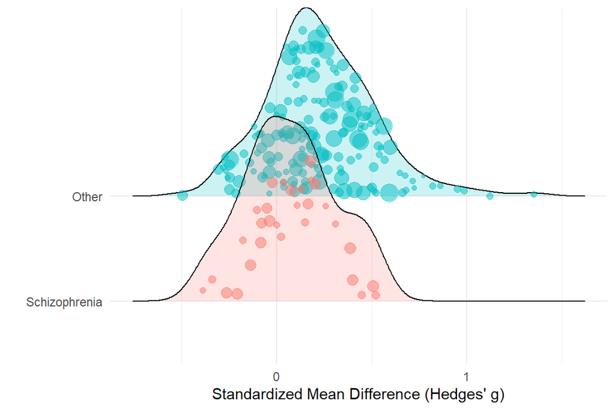

Figure 21: Distribution of effect size estimates, by diagnosis (reintegrational outcome).

````markdown
```{r diagnosis-ridge-reint}
#| label: fig-diagnosis-ridge-reint
#| fig-cap: "Distribution of effect size estimates, by diagnosis (reintegrational outcome)."
#| fig.width: 6
#| fig.height: 4
#| fig.retina: 2
#| message: false

cat_ridge(data = reintergation_dat, es = gt_pop, variable = schizophrenia, v = vgt_pop)
```
````

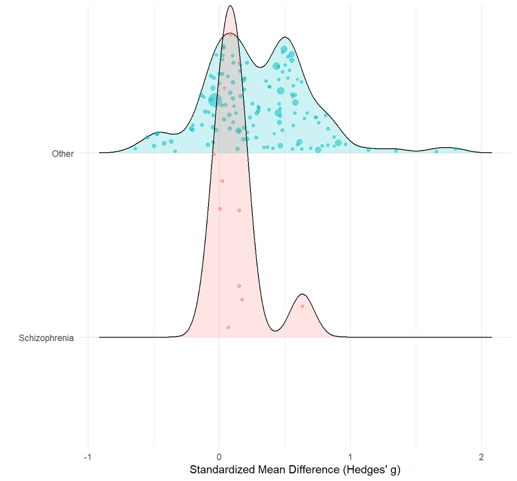

Figure 22: Distribution of effect size estimates, by diagnosis (mental health).

````markdown
```{r type-ridge-mental}
#| label: fig-type-ridge-mental
#| fig-cap: "Distribution of effect size estimates, by diagnosis (mental health)."
#| fig.height: 6.5
#| fig.retina: 2
#| message: false

cat_ridge(data = mental_health_dat, es = gt_pop, variable = schizophrenia, v = vgt_pop)
```
````

### Type of intervention

````markdown
```{r cbt-dependency-table-reint}
cbt_subgroup_dat_cross <- cat_dat_cross(
  data = reintergation_dat,
  variable = CBT_int,
  study_id = study
)

#| tbl-cap-location: top
#| label: tab-cbt-subgroup

cbt_subgroup_dat_cross |>
  knitr::kable(
    "html",
    col.names = c(
      "Outcome",
      colnames(cbt_subgroup_dat_cross)[-1]
    ),
    caption = "Dependency table for type of intervention (reintegration)"
  ) |>
  kableExtra::column_spec(1, bold = TRUE) |>
  kableExtra::footnote(
    general = "Values outside the parentheses are number of studies, with the number of samples and effect size estimates shown in the parentheses.",
    general_title = "Note: ",
    footnote_as_chunk = T
  ) |>
  kableExtra::kable_styling(bootstrap_options = c("striped", "condensed"), full_width = T)
```
````

Dependency table for type of intervention (reintegration)

| Outcome | CBT | Other |
| --- | --- | --- |
| CBT | 11 (52) | 1 (5) |
| Other | 1 (5) | 35 (150) |

Note: Values outside the parentheses are number of studies, with the number of samples and effect size estimates shown in the parentheses.

````markdown
```{r cbt-dependency-table-mental}
cbt_subgroup_dat_cross_mental <- cat_dat_cross(
  data = mental_health_dat,
  variable = CBT_int,
  study_id = study
)

#| tbl-cap-location: top
#| label: tab-cbt-subgroup-mental

cbt_subgroup_dat_cross_mental |>
  knitr::kable(
    "html",
    col.names = c(
      "Outcome",
      colnames(cbt_subgroup_dat_cross_mental)[-1]
    ),
    caption = "Dependency table for type of intervention (mental health)"
  ) |>
  kableExtra::column_spec(1, bold = TRUE) |>
  kableExtra::footnote(
    general = "Values outside the parentheses are number of studies, with the number of samples and effect size estimates shown in the parentheses.",
    general_title = "Note: ",
    footnote_as_chunk = T
  ) |>
  kableExtra::kable_styling(bootstrap_options = c("striped", "condensed"), full_width = T)
```
````

Dependency table for type of intervention (mental health)

| Outcome | CBT | Other |
| --- | --- | --- |
| CBT | 11 (46) | 1 (2) |
| Other | 1 (2) | 31 (95) |

Note: Values outside the parentheses are number of studies, with the number of samples and effect size estimates shown in the parentheses.

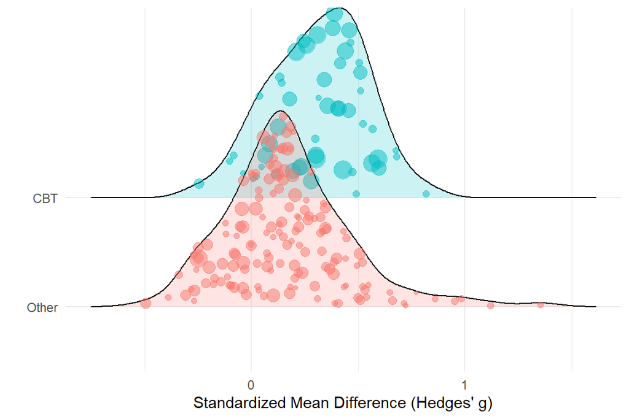

Figure 23: Distribution of effect size estimates, by type of intervention (reintegrational outcome).

````markdown
```{r cbt-ridge-reint}
#| label: fig-cbt-ridge-reint
#| fig-cap: "Distribution of effect size estimates, by type of intervention (reintegrational outcome)."
#| fig.width: 6
#| fig.height: 4
#| fig.retina: 2
#| message: false

cat_ridge(data = reintergation_dat, es = gt_pop, variable = CBT_int, v = vgt_pop)
```
````

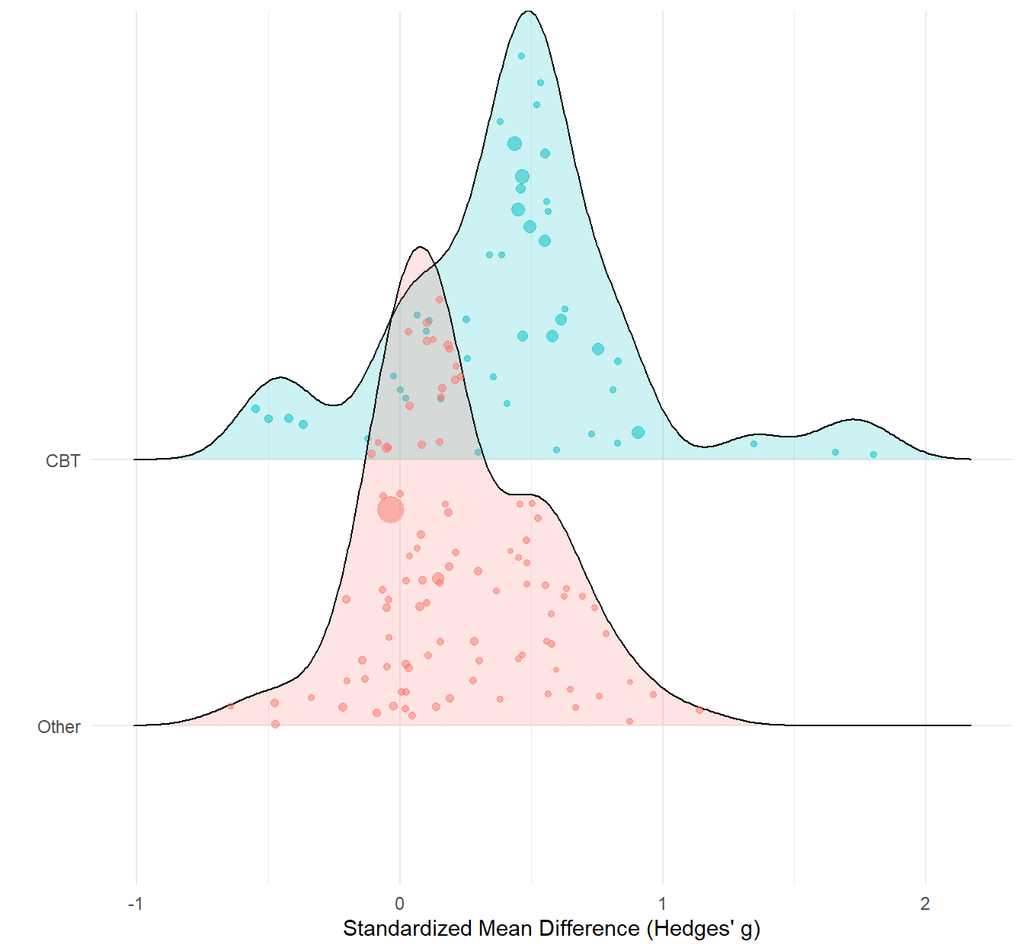

Figure 24: Distribution of effect size estimates, by type of intervention (mental health).

````markdown
```{r cbt-ridge-mental}
#| label: fig-cbt-ridge-mental
#| fig-cap: "Distribution of effect size estimates, by type of intervention (mental health)."
#| fig.height: 6.5
#| fig.retina: 2
#| message: false

cat_ridge(data = mental_health_dat, es = gt_pop, variable = CBT_int, v = vgt_pop)
```
````

### Type of test

````markdown
```{r test-type-dependency-table-reint}
test_type_dat <-
  reintergation_dat |>
  filter(test_type != "Raw events")

test_type_dat_cross <- cat_dat_cross(
  data = test_type_dat,
  variable = test_type,
  study_id = study
)

#| tbl-cap-location: top
#| label: tab-test-type-subgroup

test_type_dat_cross |>
  knitr::kable(
    "html",
    col.names = c(
      "Outcome",
      colnames(test_type_dat_cross)[-1]
    ),
    caption = "Dependency table for type of test (reintegration)"
  ) |>
  kableExtra::column_spec(1, bold = TRUE) |>
  kableExtra::footnote(
    general = "Values outside the parentheses are number of studies, with the number of samples and effect size estimates shown in the parentheses.",
    general_title = "Note: ",
    footnote_as_chunk = T
  ) |>
  kableExtra::kable_styling(bootstrap_options = c("striped", "condensed"), full_width = T)
```
````

Dependency table for type of test (reintegration)

| Outcome | Clinician-rated measure | Self-reported |
| --- | --- | --- |
| Clinician-rated measure | 12 (36) | 5 (8) |
| Self-reported | 5 (8) | 38 (165) |

Note: Values outside the parentheses are number of studies, with the number of samples and effect size estimates shown in the parentheses.

````markdown
```{r test-type-dependency-table-mental}
test_type_dat_mental <-
  mental_health_dat |>
  filter(test_type != "Raw events")


test_type_dat_cross_mental <- cat_dat_cross(
  data = test_type_dat_mental,
  variable = test_type,
  study_id = study
)

#| tbl-cap-location: top
#| label: tab-test-type-subgroup-mental

test_type_dat_cross_mental |>
  knitr::kable(
    "html",
    col.names = c(
      "Outcome",
      colnames(test_type_dat_cross_mental)[-1]
    ),
    caption = "Dependency table for type of test (mental health)"
  ) |>
  kableExtra::column_spec(1, bold = TRUE) |>
  kableExtra::footnote(
    general = "Values outside the parentheses are number of studies, with the number of samples and effect size estimates shown in the parentheses.",
    general_title = "Note: ",
    footnote_as_chunk = T
  ) |>
  kableExtra::kable_styling(bootstrap_options = c("striped", "condensed"), full_width = T)
```
````

Dependency table for type of test (mental health)

| Outcome | Clinician-rated measure | Self-reported |
| --- | --- | --- |
| Clinician-rated measure | 14 (41) | 5 (11) |
| Self-reported | 5 (18) | 32 (100) |

Note: Values outside the parentheses are number of studies, with the number of samples and effect size estimates shown in the parentheses.

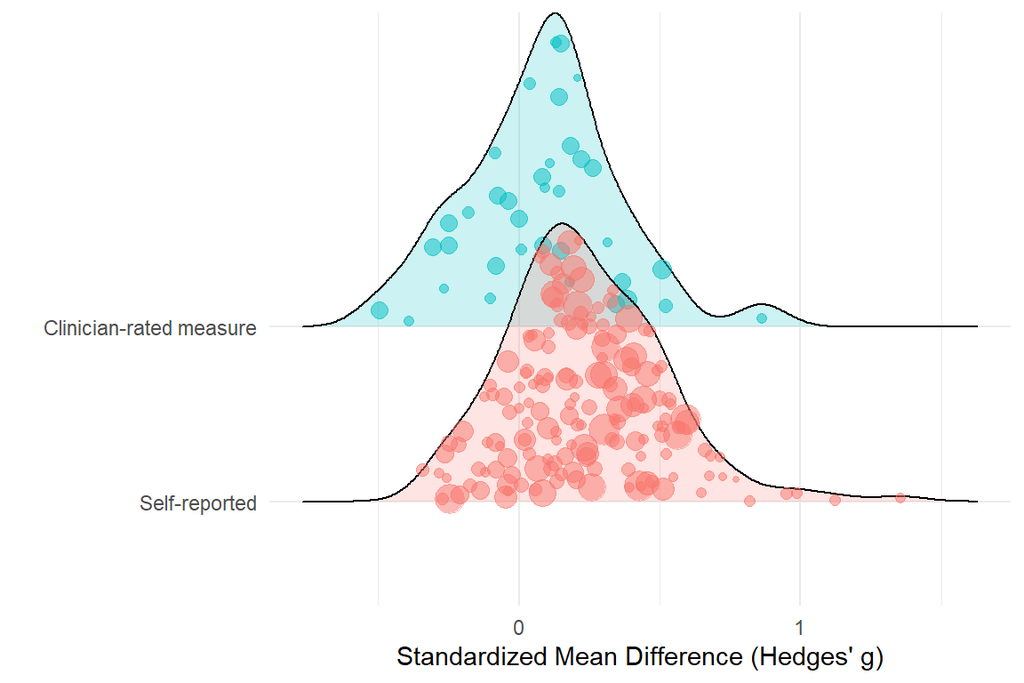

Figure 25: Distribution of effect size estimates, by type of test (reintegrational outcome).

````markdown
```{r test-type-ridge-reint}
#| label: fig-test-type-ridge-reint
#| fig-cap: "Distribution of effect size estimates, by type of test (reintegrational outcome)."
#| fig.width: 6
#| fig.height: 4
#| fig.retina: 2
#| message: false

cat_ridge(data = test_type_dat, es = gt_pop, variable = test_type, v = vgt_pop)
```
````

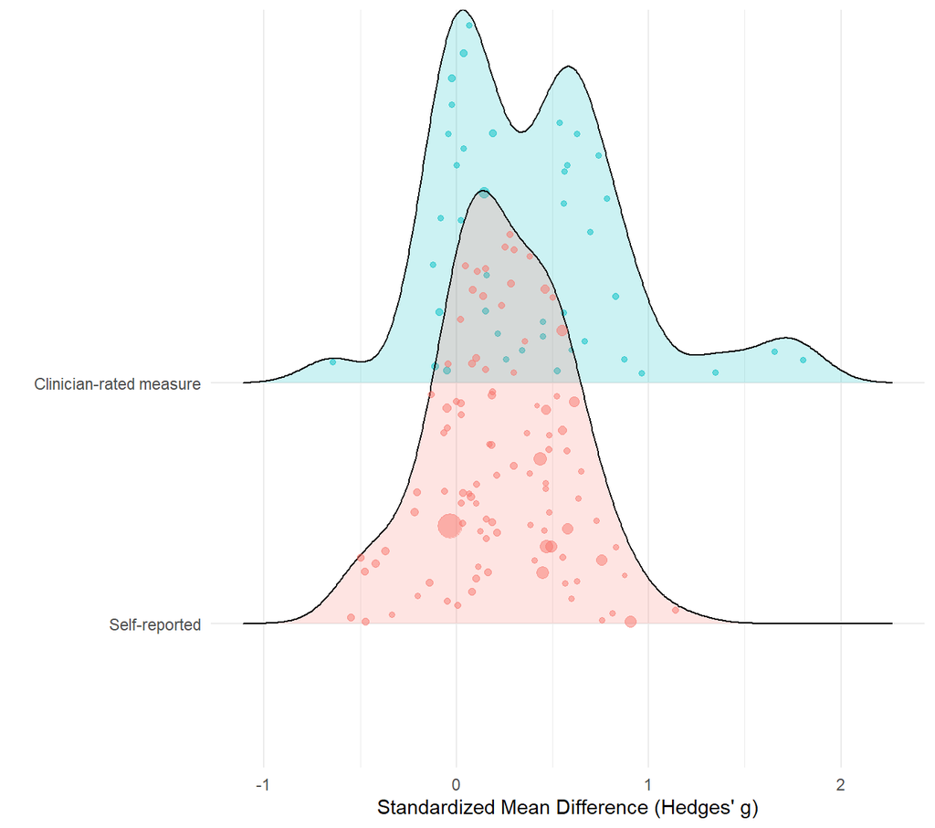

Figure 26: Distribution of effect size estimates, by type of test (mental health).

````markdown
```{r test-type-ridge-mental}
#| label: fig-test-type-ridge-mental
#| fig-cap: "Distribution of effect size estimates, by type of test (mental health)."
#| fig.height: 6.2
#| fig.retina: 2
#| message: false

cat_ridge(data = test_type_dat_mental, es = gt_pop, variable = test_type, v = vgt_pop)
```
````

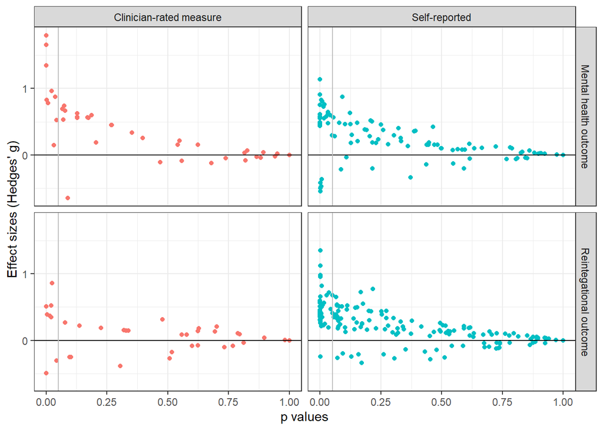

````markdown
```{r es-pval-plot-reint}
#| label: fig-es-pval-reint
#| fig-cap: "Distributions of effect size by p values and outcome measure type."
#| fig.width: 8
#| fig.height: 6
#| fig.retina: 2
#| message: false

test_type_dat_all <-
  gb_dat |>
  filter(test_type != "Raw events") |>
  mutate(
    p_val = 2 * ( 1 - pnorm( abs(gt_pop) / sqrt(vgt_pop) ) ),
  )

ggplot(test_type_dat_all, aes(y = gt_pop, x = p_val, color = test_type)) +
geom_point() +
geom_hline(yintercept = 0) +
geom_vline(xintercept = .05, color = "gray") +
facet_grid(outcome_construct~test_type) +
theme_bw() +
theme(legend.position="none") +
labs(x = "p values", y = "Effect sizes (Hedges' g)")
```
````

### ITT vs. TOT

### RCT vs. QES

### Type of control

### Low vs. high risk of bias (RoB)

### Preregistered vs. not preregistered studies

````markdown
```{r prereg-status-dependency-table}
prereg_dat_cross <- cat_dat_cross(
  data = reintergation_dat,
  variable = prereg_chr,
  study_id = study
)

#| tbl-cap-location: top
#| label: tab-published

prereg_dat_cross |>
  knitr::kable(
    "html",
    col.names = c(
      "Preregistration status",
      colnames(prereg_dat_cross)[-1]
    ),
    caption = "Dependency table for preregistration status (reintegration)"
  ) |>
  kableExtra::column_spec(1, bold = TRUE) |>
  kableExtra::footnote(
    "Values outside the parentheses are number of studies, with the number of samples and effect size estimates shown in the parentheses.",
    footnote_as_chunk = T
  ) |>
  kableExtra::kable_styling(bootstrap_options = c("striped", "condensed"), full_width = T)
```
````

Dependency table for preregistration status (reintegration)

| Preregistration status | Not preregistered | Preregistered |
| --- | --- | --- |
| Not preregistered | 22 (61) | - |
| Preregistered | - | 23 (141) |

Note: Values outside the parentheses are number of studies, with the number of samples and effect size estimates shown in the parentheses.

````markdown
```{r}
gb_dat |>
  summarise(
    prereg_chr = unique(prereg_chr),
    n_es = n(),
    .by = study
  ) |>
  summarise(
    N_studies = n_distinct(study),
    N_es = sum(n_es),
    .by = prereg_chr
  )
```
````

```
# A tibble: 2 × 3
  prereg_chr        N_studies  N_es
  <chr>                 <int> <int>
1 Preregistered            24   225
2 Not preregistered        24   118
```

**Reintegration**

````markdown
```{r}
reintergation_dat |>
  summarise(
    prereg_chr = unique(prereg_chr),
    n_es = n(),
    .by = study
  ) |>
  summarise(
    N_studies = n_distinct(study),
    N_es = sum(n_es),
    .by = prereg_chr
  )
```
````

```
# A tibble: 2 × 3
  prereg_chr        N_studies  N_es
  <chr>                 <int> <int>
1 Preregistered            23   141
2 Not preregistered        22    61
```

**Mental health**

````markdown
```{r}
mental_health_dat |>
  summarise(
    prereg_chr = unique(prereg_chr),
    n_es = n(),
    .by = study
  ) |>
  summarise(
    N_studies = n_distinct(study),
    N_es = sum(n_es),
    .by = prereg_chr
  )
```
````

```
# A tibble: 2 × 3
  prereg_chr        N_studies  N_es
  <chr>                 <int> <int>
1 Preregistered            21    84
2 Not preregistered        20    57
```

## Continuous moderators

````markdown
```{r, continuous-mod-reint}
var_labels <- c(
  "Mean age" = "age",
  "Percent Male" = "male_pct",
  "Total Number of Sessions" = "sessions",
  "Sessions per Week" = "intensity",
  "Length of Intervention (in Weeks)" = "duration",
  "Weeks After End of Intervention" = "timing",
  "Weeks from Baseline" = "weeks_from_baseline"
)

continuous_descriptives <-
 reintergation_dat |>
  summarise(
    age = mean(age_mean),
    male_pct = mean(male_pct),
    sessions = mean(total_number_of_sessions),
    intensity = mean(sessions_per_week),
    duration = mean(duration_in_weeks),
    timing = mean(time_after_end_intervention_weeks),
    weeks_from_baseline = mean(time_from_baseline_weeks),
    .by = study
  )

continuous_descriptives_tab <-
  continuous_descriptives |>
  #pivot_longer(
  #  cols = age:male_pct,
  #  names_to = "var",
  #  values_to = "val"
  #) |>
  #arrange(var)
  gather(var, val, age, male_pct, sessions, intensity, duration, timing, weeks_from_baseline) |>
  summarise(
    `% Missing` = 100 * mean(is.na(val)),
    Mean = mean(val, na.rm = TRUE),
    SD = sd(val, na.rm = TRUE),
    Min = min(val, na.rm = TRUE),
    LQ = quantile(val, na.rm = TRUE)[2],
    Median = median(val, na.rm = TRUE),
    UQ = quantile(val, na.rm = TRUE)[4],
    Max = max(val, na.rm = TRUE),
    .by = var
  ) |>
  mutate(
    var = factor(var, levels = var_labels, labels = names(var_labels))
  )

#| tbl-cap-location: top
#| label: tab-continuous-characteristics-reint
knitr::kable(
  continuous_descriptives_tab,
  caption = "Distribution of continuous moderators (reintegration)",
  col.names = c("Variable", colnames(continuous_descriptives_tab)[-1]),
  digits = 1,
  booktabs = TRUE
) |>
  kable_styling(bootstrap_options = c("striped", "condensed"), full_width = FALSE) |>
  collapse_rows(1, valign = "top")
```
````

Distribution of continuous moderators (reintegration)

| Variable | % Missing | Mean | SD | Min | LQ | Median | UQ | Max |
| --- | --- | --- | --- | --- | --- | --- | --- | --- |
| Mean age | 0.0 | 40.7 | 9.1 | 24.9 | 35.6 | 40.8 | 43.8 | 67.4 |
| Percent Male | 2.2 | 45.8 | 23.0 | 0.0 | 31.5 | 45.7 | 67.4 | 79.5 |
| Total Number of Sessions | 2.2 | 21.2 | 22.0 | 3.0 | 8.0 | 12.0 | 24.0 | 104.0 |
| Sessions per Week | 2.2 | 1.3 | 1.5 | 0.1 | 1.0 | 1.0 | 1.0 | 10.5 |
| Length of Intervention (in Weeks) | 0.0 | 18.6 | 17.0 | 4.0 | 8.0 | 12.0 | 24.0 | 78.0 |
| Weeks After End of Intervention | 0.0 | 6.0 | 10.2 | 0.0 | 0.0 | 1.0 | 6.5 | 52.0 |
| Weeks from Baseline | 0.0 | 24.6 | 22.8 | 6.0 | 12.0 | 18.0 | 26.0 | 130.0 |

````markdown
```{r, continuous-mod-mental}
var_labels_mental <- c(
  "Mean age" = "age",
  "Percent Male" = "male_pct",
  "N Sessions" = "sessions",
  "Sessions Week" = "intensity",
  "Length" = "duration",
  "Weeks After Intervention" = "timing",
  "Weeks Baseline" = "weeks_from_baseline"
)

continuous_descriptives_mental <-
 mental_health_dat |>
  summarise(
    age = mean(age_mean),
    male_pct = mean(male_pct),
    sessions = mean(total_number_of_sessions),
    intensity = mean(sessions_per_week),
    duration = mean(duration_in_weeks),
    timing = mean(time_after_end_intervention_weeks),
    weeks_from_baseline = mean(time_from_baseline_weeks),
    .by = study
  )

continuous_descriptives_tab_mental <-
  continuous_descriptives_mental |>
  #pivot_longer(
  #  cols = age:male_pct,
  #  names_to = "var",
  #  values_to = "val"
  #) |>
  #arrange(var)
  gather(var, val, age, male_pct, sessions, intensity, duration, timing, weeks_from_baseline) |>
  summarise(
    `% Missing` = 100 * mean(is.na(val)),
    Mean = mean(val, na.rm = TRUE),
    SD = sd(val, na.rm = TRUE),
    Min = min(val, na.rm = TRUE),
    LQ = quantile(val, na.rm = TRUE)[2],
    Median = median(val, na.rm = TRUE),
    UQ = quantile(val, na.rm = TRUE)[4],
    Max = max(val, na.rm = TRUE),
    .by = var
  ) |>
  mutate(
    var = factor(var, levels = var_labels_mental, labels = names(var_labels_mental))
  )

#| tbl-cap-location: top
#| label: tab-continuous-characteristics-mental
knitr::kable(
  continuous_descriptives_tab_mental,
  caption = "Distribution of continuous moderators (mental health)",
  col.names = c("Variable", colnames(continuous_descriptives_tab)[-1]),
  digits = 1,
  booktabs = TRUE
) |>
  kable_styling(bootstrap_options = c("striped", "condensed"), full_width = FALSE) |>
  collapse_rows(1, valign = "top")
```
````

Distribution of continuous moderators (mental health)

| Variable | % Missing | Mean | SD | Min | LQ | Median | UQ | Max |
| --- | --- | --- | --- | --- | --- | --- | --- | --- |
| Mean age | 0.0 | 39.6 | 9.4 | 21.6 | 34.8 | 39.8 | 43.1 | 67.4 |
| Percent Male | 2.4 | 44.3 | 23.1 | 0.0 | 28.7 | 45.7 | 64.1 | 77.8 |
| N Sessions | 2.4 | 22.0 | 22.7 | 3.0 | 9.5 | 13.0 | 24.0 | 104.0 |
| Sessions Week | 2.4 | 1.3 | 1.6 | 0.1 | 1.0 | 1.0 | 1.0 | 10.5 |
| Length | 0.0 | 19.6 | 17.6 | 4.0 | 10.0 | 12.0 | 26.0 | 78.0 |
| Weeks After Intervention | 0.0 | 7.0 | 11.1 | 0.0 | 0.0 | 1.0 | 8.0 | 52.0 |
| Weeks Baseline | 0.0 | 26.6 | 24.3 | 6.0 | 12.0 | 18.0 | 29.0 | 130.0 |

### Density Plots

#### Age distribution across studies

````markdown
```{r density-plot-function}
density_plot <- function(variable, x_title, data, color = "cornflowerblue") {
  require(dplyr)
  require(tidyr)
  require(ggplot2)
  require(rlang)
  require(MetBrewer)

  var_exp <- enquo(variable)
  var_str <- as_label(var_exp)

  data |>
    ggplot(aes(x = !!var_exp)) +
    geom_density(fill = color, alpha = 0.8) +
    geom_rug(alpha = 0.7, length = unit(0.04, "npc")) +
    scale_y_continuous(labels = scales::label_number(accuracy = 10^(-3))) +
    theme_minimal() +
    labs(x = x_title, y = "")
}
```
````

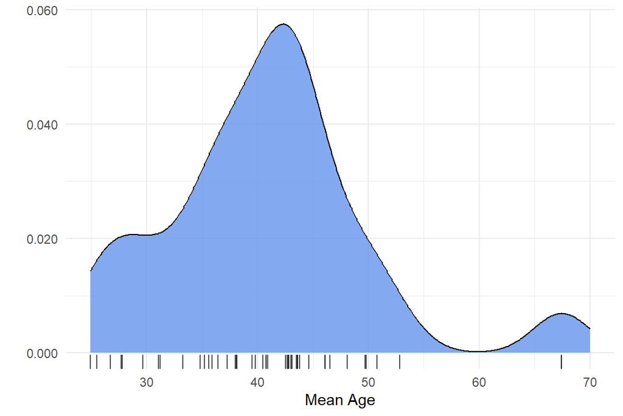

Figure 27: Distribution of average age in a study (reintegrational).

````markdown
```{r age-density-reint}
#| label: fig-age-density-reint
#| fig-cap: "Distribution of average age in a study (reintegrational)."
#| fig.width: 6
#| fig.height: 4
#| fig.retina: 2
#| message: false

age_density <- density_plot(age, "Mean Age", continuous_descriptives)

age_density + expand_limits(x = 70)
```
````

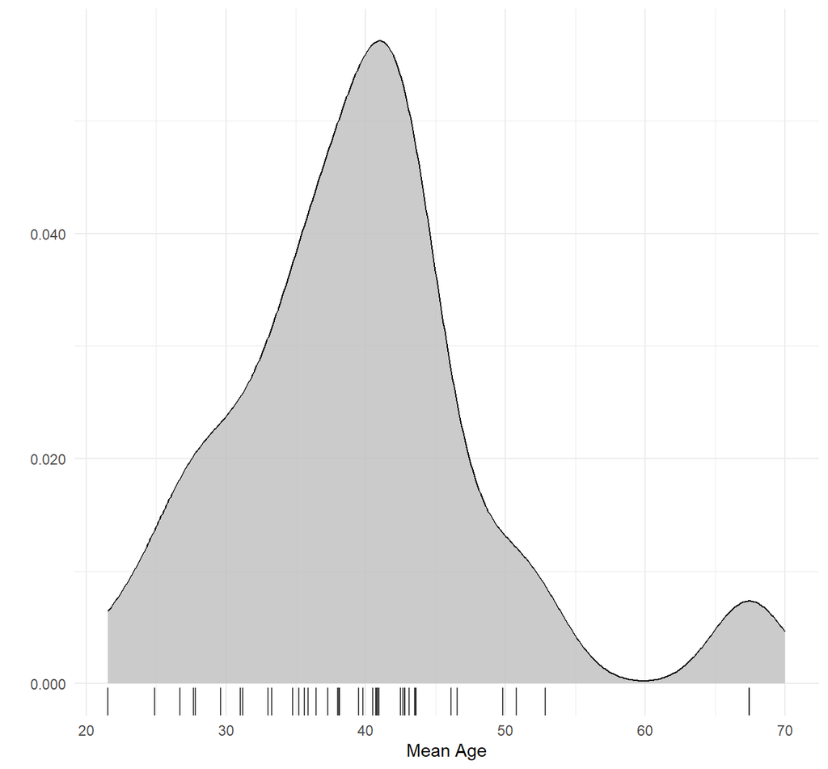

Figure 28: Distribution of average age in a study (mental health).

````markdown
```{r age-density-mental}
#| label: fig-age-density-mental
#| fig-cap: "Distribution of average age in a study (mental health)."
#| fig.height: 6.5
#| fig.retina: 2
#| message: false

age_density_mental <- density_plot(age, "Mean Age", continuous_descriptives_mental, color = "gray")

age_density_mental + expand_limits(x = 70)
```
````

#### Percent males in sample distribution across studies

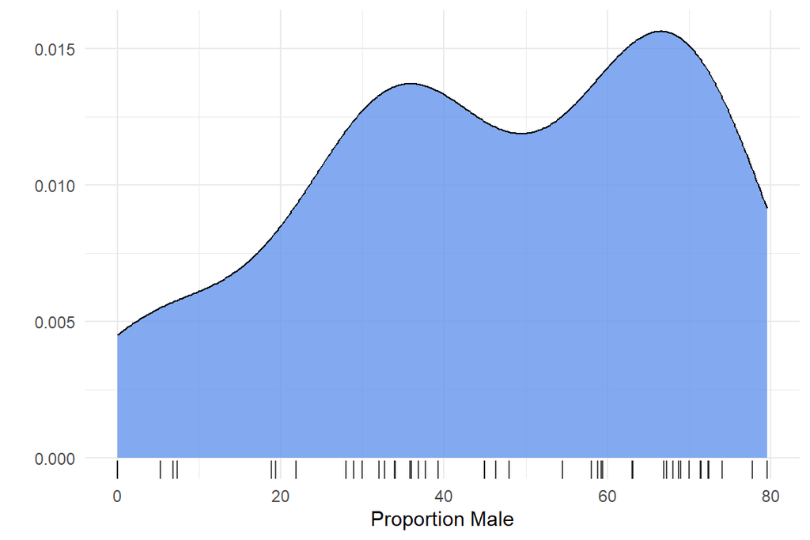

Figure 29: Distribution proportion of males in each study (reintegration).

````markdown
```{r males-density-reint}
#| label: fig-males-density-reint
#| fig-cap: "Distribution proportion of males in each study (reintegration)."
#| fig.width: 6
#| fig.height: 4
#| fig.retina: 2
#| message: false

male_density <- suppressWarnings(density_plot(male_pct, "Proportion Male", continuous_descriptives))
male_density
```
````

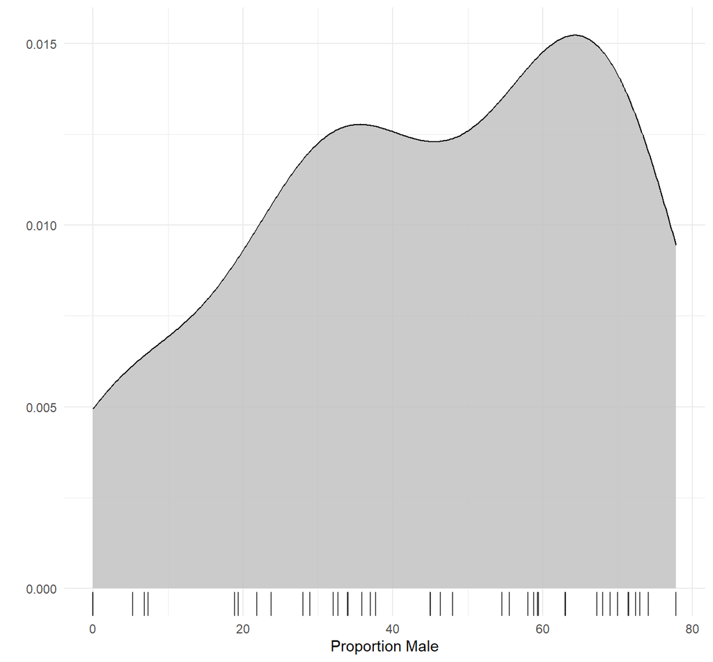

Figure 30: Distribution proportion of males in each study (mental health).

````markdown
```{r males-density-mental}
#| label: fig-males-density-mental
#| fig-cap: "Distribution proportion of males in each study (mental health)."
#| fig.height: 6.5
#| fig.retina: 2
#| message: false

male_density_mental <- suppressWarnings(density_plot(male_pct, "Proportion Male", continuous_descriptives_mental, color = "gray"))
male_density_mental
```
````